# Supplementary material 2

Landscape-scaled technological structure in surface-collected Quina scrapers

Authors

Affiliations

Published

September 8, 2026

# 1 Summary

## 1.1 What This Document Is

This is Supplementary Material 2, the statistical supplement to the main paper. It reports one Bayesian analysis in full: the data, the model, the priors, how the model was fitted and checked, the posterior estimates, the decisions drawn from them, and how far those decisions depend on choices that could have been made differently.

The analysis follows two published guidelines. Kruschke (2021) specifies what a completed Bayesian analysis should report, item by item, and we follow this specification in this document. Section 14 provides the checklist and shows where each requirement is answered in this document. Gelman, Vehtari, McElreath, et al. (2026) describe how model development should proceed before there is a final analysis to report: fit a model, check how well it performs, find the problems, change the model, and go round again. They argue that a real analytical problem is better understood by comparing several plausible models than by relying on one. We follow them in three further respects. First, we state what the study is trying to estimate, and the design that has to deliver it, before any model appears (Section 3), so that what the two research questions can and cannot settle is fixed in the open rather than inferred from wide intervals later. Second, we set out all eleven fits together with the reason each exists (Section 5), including the two that record a defect the analysis found in itself. Third, we check the calibration of the reference posterior, which no convergence diagnostic can establish (Section 10.5).

This supplement follows the order in which the analysis was conducted, from Section 3 to Section 7, and puts the reporting checklist at the end. A reader auditing coverage can work through the checklist without interrupting the narrative. We introduce the technical vocabulary used throughout in Section 2. The appendices give the complete tables, the model code and the diagnostics.

## 1.2 What Our Bayesian Model Analysed

We looked at 165 surface-collected Quina scrapers from 26 localities in two basins, Binchuan and Huangping. Seven attributes were recorded from each specimen: its thickness, its overall size, its geometric index of unifacial reduction (GIUR), the retouched share of its perimeter, its total scar count, its edge angle, and the number of retouch generations recorded on it. Three further attributes describe the locality: which basin it lies in, how high it sits above the channel, and how far it is from the channel. Each locality attribute is the same for every specimen collected from that locality.

Our multilevel model takes all seven attributes at once, so that a single locality structure is shared across them instead of seven separate analyses being run and compared afterwards. The model gives every locality its own baseline for every attribute, and it answers two questions:

- How much of the variation in each attribute occurs between localities rather than among specimens within a locality?
- And how much of that difference between localities do the three landscape attributes explain?

## 1.3 What Our Bayesian Model Found

### 1.3.1 Q1: Do the Localities Differ from One Another?

Yes, for 3 of the seven measurements: Geometric mean size, Total scars, Thickness. Between 22% and 29% of the variation in those measures sits between localities rather than between specimens within a locality, and for 2 of them the finding survives every one of the prior settings the model was refitted under. The remaining 4 are undecided (Section 6.2).

### 1.3.2 Q2: Do Basin, Elevation or Distance to the Channel Explain the Differences?

Not clearly. Of the 21 landscape effects estimated, 0 show an effect large enough to matter, 1 is close enough to zero to be called practically negligible, and the remaining 20 are too uncertain to separate. Adding all three landscape attributes to a model that lacks them barely moves the share of variation sitting between localities, the median change across the seven measures being +13.0% (Section 6.2, Section 6.3).

An undecided result is a finding rather than a failure to obtain one, so for each landscape effect we report the smallest effect the data can rule out, in the units of the measurement itself. For the three best-resolved effects those bounds are Retouched perimeter with height above channel (z), +/- 15 % in the odds; GIUR with height above channel (z), +/- 37 % in the odds; Retouched perimeter with distance to channel (z), +/- 35 % in the odds. Table 22 gives the same bound for all 21 effects, in degrees, retouch generations, or percentages of the measurement.

## 1.4 What Our Bayesian Model Cannot Settle

Basin, height above the channel and distance to the channel are recorded once per locality, so the three landscape attributes are estimated from 26 localities however many specimens each of them contributes. That number, together with the very uneven sizes of the assemblages behind it, sets the resolution of both research questions. Section 3.2 gives the argument in full, and Section 6.6 adds three limitations that apply to particular measures.

# 2 Reading Guide

Before discussing the Bayesian Model in detail, we provide definitions of the key terms to guide the reader. Each term is glossed again, in one clause, where it first appears in the main narrative below.

| Term | What it means here |
| --- | --- |
| Posterior distribution | The distribution of a quantity (a slope, a share of variance) after the data have been combined with the prior. Every number in this document is a summary of one. |
| 95% credible interval | The central range containing 95% of the posterior. It says where the quantity lies, given this model and these data. A confidence interval answers a different question, about the long-run behaviour of… |
| ROPE | Region of practical equivalence: the band of values around zero that the analysis is willing to treat as no effect. Calling an effect absent means showing that the posterior sits inside that band. |
| Intraclass correlation (ICC) | The share of a measure’s variation that sits between localities rather than between specimens within a locality. |
| Link scale, and dividing by the link-scale SD | Thickness is modelled on a logarithmic scale, GIUR on a log-odds scale, edge angle in degrees. A slope on one of those scales cannot be compared with a slope on another until each is divided by the sp… |
| Partial pooling | A locality with one specimen is estimated partly from the other localities, so its level is pulled towards the overall level. It stops a single-specimen locality from being read as a well-measured one… |
| Prior predictive check | Simulating data from the prior alone, before the real data are used, to confirm that the prior puts no weight on physically impossible values. |
| Posterior predictive check | Simulating data from the fitted model and comparing them with the observed data, to see what the model reproduces and what it misses. |
| R-hat and effective sample size | Diagnostics of the simulation rather than of the archaeology. R-hat near 1 means the independently started chains agree; the effective sample size says how many independent draws the correlated ones a… |
| Rank plot | A picture of the same thing. Pool the draws from all four chains, rank them, and count how many of each chain’s draws fall in each rank bin. Four flat, overlapping lines mean the chains explored the s… |
| Sensitivity analysis | Refitting under different priors to find out which conclusions depend on the prior and which do not. |

# 3 The Estimand and the Design

Gelman, Vehtari, McElreath, et al. (2026, ch. 10) set out the chain any empirical claim depends on. A generative theory motivates an estimand; the theory and the estimand together justify a design; the design yields a sample; and a statistical model, the estimator, turns that sample into an estimate. A reader can walk the chain backwards from a conclusion to find the link that fails. This section names them for the present study, because three facts about the design set the resolution of everything that follows. In addition, the specimen count overstates what the design delivers for the second research question.

## 3.1 Theory and Estimand

The theory is that the technological character of a Quina assemblage varies with where in a valley system its makers worked, so that assemblages from different parts of a basin should differ in systematic ways.

Two quantities to be estimated follow from our theory (Section 4.2). Q1 is the proportion of the variation in each of the seven measures that occurs between localities rather than among specimens within the same locality. Q2 is the difference in each measure associated with belonging to one basin rather than the other, together with the change associated with a one-standard-deviation increase in height above the channel or in distance from the channel, the other two attributes held fixed.

Q2 estimates an association. The study did not assign the localities their elevations, it states no causal diagram, and it derives no adjustment set from one. A slope near zero therefore means that the landscape attribute fails to predict the measure across these 26 localities.

## 3.2 Design and Sample

Three features of how the material was collected constrain our results.

For Q2 the unit of information is the locality, we have 26 of these. Basin, height above the channel and distance to the channel are recorded once per locality and are identical for every specimen collected there. The 165 specimens sharpen the estimate of within-locality variation and of each locality’s overall level. They add no independent information about the three landscape slopes, so collecting more scrapers from the same localities would describe those localities better while leaving Q2 where it is. The same fact rules out landscape slopes that vary from locality to locality, which is why the question of whether the landscape effects differ between the two basins has to be put at basin level (Section 6.4).

The basin comparison rests on a single contrast, between 21 localities in Binchuan and 5 in Huangping. The width of the interval estimate is what reports the uncertainty that follows from it.

The assemblages are very uneven. One locality contributes 49 of the 165 specimens, and 10 localities contribute one specimen each. Partial pooling estimates a poorly sampled locality partly from the others instead of treating its level as precisely known (Section 12.2). This improves the estimate without creating information the sample does not contain.

Section 6.6 returns to these three limitations once the estimates are in, and adds three that arise from the model rather than from the sample.

# 4 The Analysis

## 4.1 Why the Analysis Is Bayesian

Cf. BARG Preamble A.

Four considerations led us to a Bayesian treatment. The seven measures on a Quina scraper are not on one scale – thickness and overall size are positive and right-skewed, GIUR and the retouched share of the perimeter are proportions ranging 0-1, the scar count is a count, and the edge angle and the number of retouch generations are treated as unbounded (Section 4.3). This requires a single multivariate model that gives each measure the likelihood its scale calls for, while still sharing one locality-level random structure across all seven. A Bayesian model is the most straightforward way to handle these diverse variables and the nested structure.

Q1 asks for the share of link-scale variance attributable to locality, an intraclass correlation built from a variance component and a residual variance that are themselves functions of several parameters; under MCMC that ratio is computed draw by draw and inherits a genuine interval, with no approximation and no delta-method step. The variance component Q1 asks about is estimated from 26 clusters (Section 3.2), a number at which asymptotic intervals deserve little trust while posterior intervals require no such argument.

Q2 puts a claim of absence under test, which a frequentist test can only fail to reject, whereas a posterior distribution combined with a region of practical equivalence can accept it, reject it, or report that the data do not decide (Section 6.1).

## 4.2 Goals and the Two Research Questions

Cf. BARG Preamble B.

Our study has two goals. The first is estimation: the size of each landscape effect and the amount of locality-level variation, with the uncertainty on each. The second is decision: whether each landscape effect is small enough to treat as practically absent.

Formal model selection is outside the scope as well. One model answers the two research questions, and the analysis estimates its parameters instead of comparing competing scientific hypotheses. It computes no marginal likelihood and chooses no model on predictive performance. That matters for reading Section 5, which reports 11 fits. The fits measure how far the conclusions depend on reasonable alternative choices, and none is selected as best. Gelman, Vehtari, McElreath, et al. (2026, ch. 9) draw the same distinction, treating a series of fits as a way to understand one model rather than as a contest among models.

Q1 asks whether technological variation exists between localities at all. The locality-level variance component answers it through the intraclass correlation (ICC), the proportion of a measure’s total variation that occurs between localities rather than among specimens within the same locality (Section 12.1, Section 6.2). In plainer terms, Q1 asks how much specimens from one locality resemble each other, relative to how much the localities differ.

Q2 asks whether basin, elevation above the channel or distance to the channel explains that between-locality variation. This is answered by population-level slopes (Section 12, Section 6.3).

The order of the questions is important. Q2 only has something to explain if Q1 shows that the localities differ in the first place.

## 4.3 Data

Cf. BARG Step 1.A.

Table 1: The variables entering the model, and their observed range in the analysed sample.

| Variable | Role | Type | Observed |
| --- | --- | --- | --- |
| Thickness | response | continuous, positive (mm) | 11.0 - 51.1 |
| Geometric mean size | response | continuous, positive (mm); geometric mean of length, width and thickness | 22.2 - 71.4 |
| GIUR | response | proportion in [0, 1] | 0.2 - 1.0 |
| Retouched perimeter | response | proportion in [0, 1] | 0.2 - 1.0 |
| Total scars | response | count | 6.0 - 87.0 |
| Edge angle | response | continuous (degrees) | 45.3 - 96.3 |
| Retouch generations | response | continuous (generations) | 1.0 - 4.0 |
| Basin | predictor (locality level) | binary: Binchuan / Huangping | 46 / 119 |
| Height above channel | predictor (locality level) | continuous (m) | 25 - 187 |
| Distance to channel | predictor (locality level) | continuous (m) | 204 - 2690 |
| Locality | grouping factor | factor, 26 levels | 165 specimens in 26 localities |

`GMsize` is the geometric mean of the three linear dimensions,
$$\mathrm{GMsize} = (\mathrm{Length}\times\mathrm{Width}\times\mathrm{Thickness})^{1/3},$$
computed for each specimen. The definition lives in the analysis code rather than in any measurement protocol, and it is stated here because it has a consequence.

Thickness is one of the three factors in GMsize, so the two responses share a component. The model is fitted with `set_rescor(FALSE)`, which assumes the *residuals* of the seven responses are independent given the locality intercepts, and that assumption is not credible for this pair. In practice the consequence is limited. With `rescor = FALSE` the multivariate model factorises into seven univariate models sharing only the correlated random intercepts, so the slopes and their intervals for each response remain valid marginally. The invalid readings are confined to: any statement about the *joint* uncertainty of the thickness slope and the size slope, and any treatment of those two responses as independent evidence. The observed correlation between their locality intercepts (Section 12.2) is therefore partly mechanical.

`RG` is the mean number of retouch generations across up to three edges per specimen, so values occur in thirds rather than integers. Because averaging removes the integer support required by Poisson or negative binomial likelihoods, we used a Gaussian likelihood. An ordinal likelihood could model the discreteness, but would introduce thresholds and prevent `RG` from sharing the common link-scale ICC, standardised slope, and ROPE used for the seven jointly modelled responses. We therefore retained the Gaussian likelihood and assessed its implications with Section 11 and `ref_rg_ln`.

Two filters were applied before fitting. A specimen must have all seven measurements, and its locality must have a recorded basin, height and distance.

Table 2: Complete-case filtering. One specimen was dropped, for a missing GIUR.

| step | specimens remaining | lost at this step |
| --- | --- | --- |
| specimens in the surface Quina sheet | 166 | NA |
| matched to a locality in Site_information.xlsx | 166 | 0 |
| complete on the seven measures | 165 | -1 |
| complete on height, distance and basin | 165 | 0 |

Table 3: Localities and specimens by basin. Heqing, which appears under that name in the site table, is folded into Huangping: the two names refer to the same basin.

| Basin | localities | specimens | specimens per locality |
| --- | --- | --- | --- |
| Binchuan | 21 | 46 | 1 - 10 |
| Huangping | 5 | 119 | 6 - 49 |

The random intercept is the part of the model that enforces what Section 3.2 sets out, and it is why the intervals in Section 12 are as wide as they are.

The standardisation is specimen-weighted: `zHeight` and `zDistance` are centred and scaled over the 165 specimens rather than over the 26 localities, so a locality enters the centring and the scaling with the weight of its own assemblage. A locality-weighted standardisation would give slightly different numerical slopes on a rescaled axis. It would not change any decision, because every slope is reported divided by the link-scale SD of its own response and the ROPE moves with it.

## 4.4 Model and Likelihoods

Cf. BARG Step 1.B.

For specimen $i$ in locality $j$, each response $r$ has its own likelihood with a linear predictor on its own link scale:

$$g_r(\mu^{(r)}_{ij}) \;=\; \beta^{(r)}_{0} \;+\; \beta^{(r)}_{\text{Basin}}\,\mathrm{Basin}_j
\;+\; \beta^{(r)}_{\text{H}}\,\mathrm{zHeight}_j
\;+\; \beta^{(r)}_{\text{D}}\,\mathrm{zDistance}_j \;+\; u^{(r)}_j ,$$

$$\bigl(u^{(1)}_j,\dots,u^{(7)}_j\bigr)^{\!\top} \sim
\mathrm{MVNormal}\bigl(\mathbf 0,\;\mathbf D\,\boldsymbol\Omega\,\mathbf D\bigr),
\qquad \mathbf D=\mathrm{diag}(\sigma^{(1)}_u,\dots,\sigma^{(7)}_u).$$

Table 4: Likelihoods. The last column is the SD of the observed response on its own link scale; it is the unit in which every slope and every ROPE below is expressed.

| Response | Likelihood | Link for the mean | Auxiliary parameters | Link-scale SD |
| --- | --- | --- | --- | --- |
| Thickness | lognormal | log | sigma | 0.297 |
| Geometric mean size | lognormal | log | sigma | 0.228 |
| GIUR | zero-one-inflated beta | logit | phi, zoi, coi | 1.974 |
| Retouched perimeter | zero-one-inflated beta | logit | phi, zoi, coi | 1.530 |
| Total scars | negative binomial | log | shape | 0.563 |
| Edge angle | gaussian | identity | sigma | 8.072 |
| Retouch generations | gaussian | identity | sigma | 0.657 |

### 4.4.1 Parameters of Theoretical Interest and Nuisance Parameters

Of the 256 estimated parameters, the research questions concern the 21 population-level slopes $\beta^{(r)}_{\text{Basin}}, \beta^{(r)}_{\text{H}}, \beta^{(r)}_{\text{D}}$ (Q2) and the seven locality SDs $\sigma^{(r)}_u$ together with the ICCs derived from them (Q1). The seven intercepts, the auxiliary parameters (`sigma`, `phi`, `shape`, `zoi`, `coi`) and the 21 elements of $\boldsymbol\Omega$ make the model coherent without answering any question posed here. Section 12.2 nevertheless reports the correlations in full, because the model estimated them and BARG asks for a description of every parameter.

With 10 localities of one specimen, the locality offsets shrink hard towards the grand mean. That shrinkage is partial pooling: a locality with little data of its own is estimated partly from the others, and the caterpillar plot in Section 12.2 shows how far each is pulled. The behaviour is intended, and it is why the ICC comes from the fitted variance components rather than from a between-group variance ratio of raw locality means.

### 4.4.2 A Trap in the Zero-One-Inflated Beta Parameterisation

For GIUR and the retouched perimeter, the three predictors enter only the beta component’s mean `mu`. The inflation parameters `zoi` (the probability that a value is exactly 0 or exactly 1) and `coi` (the probability that such a value is 1 rather than 0) are pure intercepts, constant across basins, elevations and distances. Two consequences follow for every GIUR and RLI number in this report.

1. A reported slope is the effect on the **logit of the beta-component mean, conditional on the value lying strictly inside (0, 1)**. The effect on the unconditional expected GIUR is a different quantity, because that one also moves with `zoi` and `coi`.
2. The ICC for these two responses likewise comes from the beta component alone and ignores the inflation entirely.

In this sample there are 17 specimens with GIUR exactly 1 and 0 with GIUR exactly 0, and 9 and 0 for the retouched perimeter. There is therefore no zero inflation at all to model: the fitted `coi` is a posterior over “all inflated values are ones”, which the data determine almost completely, and the zero-inflation half of the family is supported by nothing. The family is effectively a one-inflated beta.

### 4.4.3 S6: Fixing coi at 1, the One-Inflated Refit

S6 is one of the six model variants in Section 5, modifying only `coi` by fixing it at 1 rather than estimating it. The reference model uses `zero_one_inflated_beta` because GIUR and retouched perimeter are proportions with boundary accumulation; however, both responses contain no zeros, so `coi` is effectively 1. Estimating it under a `beta(1, 1)` prior therefore reflects a mismatch between the generality of the distribution family and the observed data, rather than a data or coding error. S6 corrects this specification.

Setting `coi` to `constant(1)` in `barg_priors.R` gives the family the one-inflated beta shape the data actually show: mass at 1, none at 0, and the zero-inflation half deleted instead of estimated. brms implements the constant by moving `coi_GIUR` and `coi_RLI` out of the Stan `parameters` block into `transformed parameters`, so two parameters genuinely leave the sampled space instead of receiving a tight prior, and Table 17 shows S6 estimated over 254 parameters against 256 for the reference. The reference fit shows why that is worth doing: under `beta(1, 1)` and 17 ones out of 165 specimens, its posterior for GIUR’s `coi` centres on 0.962 rather than on 1, reserving 3.8% of the inflation mass for an outcome that cannot occur, which puts the probability of an exact zero at 0.0039 and predicts **0.65** zeros among the 165 specimens, where the data contain none.

No conclusion can change under the refit, and the reason is stronger than a sensitivity result. The zero-one-inflated beta likelihood factorises: an observation contributes $\mathrm{zoi}\cdot\mathrm{coi}$ if it equals 1, $\mathrm{zoi}\cdot(1-\mathrm{coi})$ if it equals 0, and $(1-\mathrm{zoi})\cdot\mathrm{Beta}(y \mid \mu, \phi)$ otherwise. The linear predictor enters only the third term; `zoi` and `coi` enter only the first two, take no predictors, and have their own priors. The posterior therefore separates, and the slopes, `phi`, the locality SDs and the locality correlation matrix come from the interior observations alone whatever value `coi` takes. S6 therefore checks that this reasoning, and the code that implements it, are both right, rather than whether the answers survive a different `coi`.

Table 5: The five landscape slopes on which the reference fit and S6 disagree most, on the link scale, ordered by the difference between the two posterior medians as a fraction of that slope’s own posterior SD. The other 16 agree more closely. The two runs are separate samplers over different Stan programs, S6 having two fewer parameters, so exact agreement is neither expected nor desirable; agreement within a small multiple of the Monte Carlo standard error is what the factorisation predicts.

| Response | Predictor | reference median | S6 median | difference | difference in MCSE | difference / posterior SD |
| --- | --- | --- | --- | --- | --- | --- |
| Geometric mean size | Height above channel (z) | -0.0264 | -0.0246 | 0.0018 | 3.7882 | 0.0563 |
| Edge angle | Distance to channel (z) | 2.7123 | 2.7694 | 0.0571 | 2.5097 | 0.0390 |
| Geometric mean size | Distance to channel (z) | 0.0370 | 0.0388 | 0.0018 | 1.8365 | 0.0336 |
| Edge angle | Height above channel (z) | 0.7915 | 0.8206 | 0.0291 | 2.4224 | 0.0311 |
| Total scars | Basin (Huangping vs Binchuan) | -0.0702 | -0.0746 | -0.0043 | 1.5596 | 0.0249 |

This document therefore reports S6 as the specification the data support and keeps the reference fit as the source of every other number.

## 4.5 Priors

Cf. BARG Step 1.C.

### 4.5.1 Why the Slope Prior Is Scaled to Each Response

Table 6: Percentage of the slope prior lying inside the response’s own ROPE, under a single unscaled normal(0, 1) and under the per-response scaling used here. One nominal specification ranges, across the seven responses, from an almost dogmatic rejection of a null effect to an almost dogmatic assertion of one; scaled to each response it is 7.97% for every one of them, by construction.

| Response | Link-scale SD | ROPE half-width | normal(0, 1) | normal(0, SD_link) |
| --- | --- | --- | --- | --- |
| Thickness | 0.297 | 0.030 | 2.37 | 7.97 |
| Geometric mean size | 0.228 | 0.023 | 1.82 | 7.97 |
| GIUR | 1.974 | 0.197 | 15.65 | 7.97 |
| Retouched perimeter | 1.530 | 0.153 | 12.16 | 7.97 |
| Total scars | 0.563 | 0.056 | 4.49 | 7.97 |
| Edge angle | 8.072 | 0.807 | 58.04 | 7.97 |
| Retouch generations | 0.657 | 0.066 | 5.24 | 7.97 |

The diagnostic that makes this more than an aesthetic point is the ratio of the posterior SD to the prior SD for each slope. A ratio near 1 means the posterior is the prior and the data contributed nothing.

Table 7: Posterior SD divided by prior SD, for every slope, under an unscaled normal(0, 1) slope prior (specification S1) and under the reference prior. Values near 1 mean the data did not move the prior. The prior SD is taken from the sample_prior = ‘only’ draws for the reference prior and analytically for normal(0, 1).

| Response | Predictor | normal(0, 1) | normal(0, SD_link) |
| --- | --- | --- | --- |
| Thickness | Basin (Huangping vs Binchuan) | 0.098 | 0.309 |
| Thickness | Height above channel (z) | 0.039 | 0.132 |
| Thickness | Distance to channel (z) | 0.068 | 0.215 |
| Geometric mean size | Basin (Huangping vs Binchuan) | 0.082 | 0.339 |
| Geometric mean size | Height above channel (z) | 0.032 | 0.140 |
| Geometric mean size | Distance to channel (z) | 0.059 | 0.237 |
| GIUR | Basin (Huangping vs Binchuan) | 0.329 | 0.179 |
| GIUR | Height above channel (z) | 0.142 | 0.074 |
| GIUR | Distance to channel (z) | 0.242 | 0.126 |
| Retouched perimeter | Basin (Huangping vs Binchuan) | 0.162 | 0.109 |
| Retouched perimeter | Height above channel (z) | 0.071 | 0.046 |
| Retouched perimeter | Distance to channel (z) | 0.099 | 0.064 |
| Total scars | Basin (Huangping vs Binchuan) | 0.186 | 0.307 |
| Total scars | Height above channel (z) | 0.074 | 0.129 |
| Total scars | Distance to channel (z) | 0.133 | 0.221 |
| Edge angle | Basin (Huangping vs Binchuan) | 0.913 | 0.271 |
| Edge angle | Height above channel (z) | 0.669 | 0.118 |
| Edge angle | Distance to channel (z) | 0.842 | 0.180 |
| Retouch generations | Basin (Huangping vs Binchuan) | 0.176 | 0.261 |
| Retouch generations | Height above channel (z) | 0.074 | 0.113 |
| Retouch generations | Distance to channel (z) | 0.117 | 0.173 |

Under an unscaled `normal(0, 1)` the Edge angle slopes have posterior/prior SD ratios of 0.67, 0.84, 0.91: the posterior is very nearly the prior, so an edge-angle result read off that fit would be mostly a restatement of the prior scale. Under the reference prior the largest of the three is 0.27. The unscaled specification is kept in the sensitivity set as S1 (Section 13), so its effect on every quantity in the report can be read off directly.

### 4.5.2 The Reference Prior

Every class receives an explicit prior with justification, following BARG Step 1.C

| Class | Prior | Reason |
| --- | --- | --- |
| `b` (slopes) | `normal(0, SD_link)` per response | one prior SD equal to the whole observed spread of that response on its own link scale: an effect as large as the response’s total variation is a priori about one SD out. Puts 7.97% of the prior insid… |
| `Intercept` | see below | fixed from the measurement scale rather than from the sample |
| `sd` (locality) | `student_t(3, 0, 2)` | heavy-tailed half-$t$; the one class not rescaled per response, and varied in S3 and S4 |
| `sigma` | `student_t(3, 0, SD_link)` | half-$t$ scaled to the response, for the same reason as `b` |
| `phi` (zoib) | `gamma(2, 0.1)` | proper, mean 20, density zero at the origin. The brms default `gamma(0.01, 0.01)` piles mass arbitrarily close to zero, where the beta density is degenerate, and makes the prior predictive distributio… |
| `shape` (negbin) | `gamma(2, 0.1)` | same; the brms default `inv_gamma(0.4, 0.3)` has an extremely heavy right tail |
| `zoi`, `coi` | `beta(1, 1)` | uniform on (0, 1); this is also the brms default, stated here rather than inherited |
| `cor` (7x7) | `lkj(1)` | uniform over correlation matrices; varied in S5 |

The intercept priors are set from what we have called plausible for a retouched flake tool before seeing these specific 165 pieces, mapped through the link. Each is far wider than the observed spread.

Table 8: Intercept priors, fixed from the measurement scale rather than from the sample.

| Response | Link | Prior | Implied 95% range on the response scale | Observed mean |
| --- | --- | --- | --- | --- |
| Thickness | log | normal(3.2, 0.7) | 6 - 100 mm | 25.0 mm |
| Geometric mean size | log | normal(3.7, 0.6) | 12 - 134 mm | 40.7 mm |
| GIUR | logit | normal(0, 1.5) | GIUR 0.05 - 0.95 | 0.75 |
| Retouched perimeter | logit | normal(0, 1.5) | 0.05 - 0.95 of the perimeter | 0.50 |
| Total scars | log | normal(3, 1.0) | 3 - 143 scars | 23 |
| Edge angle | identity | normal(65, 20) | 26 - 104 degrees | 70.0 deg |
| Retouch generations | identity | normal(3, 2) | -0.9 - 6.9 generations | 2.75 |

None of the priors used here are informed by previous work, because there is none to draw on. No published posterior or meta-analytic estimate exists for any of these seven measures in Quina assemblages; there is no prior literature on, for instance, how edge angle varies with elevation above a channel. That is why BARG item 5.B, sensitivity to a genuinely informed prior, has nothing to attach to in this analysis.

The complete prior is in Appendix A (Section 8): the rows `prior_summary()` still labels `default` and why the sampler never reaches them, the brms defaults that the explicit specification replaced, and the generated Stan prior block, whose `lprior` statements are what was actually added to the log posterior.

## 4.6 Fitting and Model Checks

We used the R package brms (Bürkner 2017) to fit the model with the cmdstanr backend, running 4 chains of 10,000 iterations for 20,000 post-warmup draws in total. Ten further fits use identical settings; Section 5 records what each one is for. Table 16 gives versions, seeds and sampler settings, and Section 10 gives the convergence and resolution diagnostics for all eleven runs.

# 5 The Model Series

We generated eleven fits but only one of them supplies the numbers in the results tables. The other ten exist because a single fit cannot show which of its answers depend on the analyst rather than on the scrapers. Gelman, Vehtari, McElreath, et al. (2026, ch. 9) treat this as the step that separates a Bayesian workflow from a Bayesian analysis: fit a series, keep the earlier members, and use them to understand the one you report. Each member of the series below differs from the reference in a single respect, so that any movement in a result can be attributed to a named choice.

[output not shown]

Two entries in the table record a specification defect, and neither defect was detected by standard diagnostics. `s1` is one of them in its own right: a single `normal(0, 1)` slope prior that takes no account of the link-scale SDs differing across the seven responses, which shows up as clear prior dominance for the edge-angle slopes (Table 7). The other defect is in the reference fit, where `coi` is estimated for a zero outcome that does not occur in the sample; `s6` is the variant that corrects it, by fixing `coi` at 1 (Section 4.4.3). Neither is a data or coding error; both are mismatches between the model specification and the data. Convergence and calibration diagnostics assess whether the fitted model is functioning properly, not whether its specification matches the intended one, so both issues emerged only by comparing fitted parameters with the characteristics of the observed data.

Fitting eleven models rather than one opens a familiar risk: a reader cannot tell from the finished document how many further specifications were tried and set aside, and a set of fits chosen after seeing the results can be made to bracket whatever range the analyst prefers. Two features of our design limit the room for that here. Each of `s1` to `s6` changes exactly one line of the reference prior, so the set is determined by the reference specification rather than by the results; and no fit was dropped, so Table 17 lists all eleven, including the 5 that produced a handful of divergent transitions. One thing the design cannot rule out is that a different analyst would have chosen a different reference, and Section 6.5 reports how much of the answer that choice governs.

# 6 Results

Cf. BARG Step 4.E, which requires every decision to appear beside the estimate and interval it rests on.

Figure 1 answers both of our questions at a glance. The sections that follow give the rule those answers are drawn from, then answers each question in turn, then states how much of the answer depends on the prior, and finally what our design cannot settle.

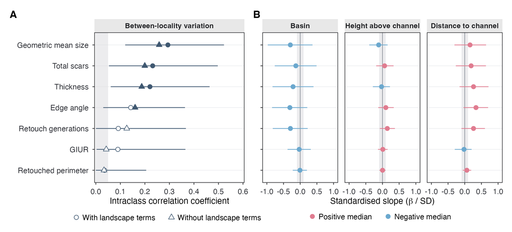

Figure 1: **A** (Q1): the locality share of link-scale variance for each response. Circles are the model with the landscape terms, triangles the intercept-only model, joined by a line. Filled circles mark responses whose 95% interval clears the 0.05 negligibility band (shaded). **B** (Q2): the 21 landscape slopes, each divided by the link-scale SD of its own response so that all seven share one axis and the ROPE is a single band at +/- 0.1. The basin slope is Huangping relative to Binchuan; height and distance are standardised, so their slopes are the change over one SD of the predictor. Rows are in the same order in both panels. Any slope whose posterior SD is still more than half its prior SD is drawn grey and hollow, because it has not been informed enough by the data to be read as an estimate.

## 6.1 The Decision Rule and the ROPE

Cf. BARG Step 4.A.

The substantive question asks how large an effect is and also whether it is small enough to treat as absent. An interval alone answers only the first, and so does a $p$-value, which can fail to reject and nothing more. The rule used here is Kruschke’s (2018) three-way decision against a region of practical equivalence, or ROPE, meaning the band of values around the null value that the analysis is willing to treat as no effect:

| Decision | Condition (either suffices) |
| --- | --- |
| **Reject the null value** | the 95% credible interval lies entirely outside the ROPE, **or** less than 2.5% of the posterior mass is inside it |
| **Accept the null value** | the 95% credible interval lies entirely inside the ROPE, **or** more than 95% of the posterior mass is inside it |
| **Undecided** | neither of the above |

An undecided verdict is a substantive outcome in its own right. It means the data are compatible both with an effect large enough to matter and with none, and Section 6.3.1 turns that into a quantitative statement of what the design was able to exclude.

### 6.1.1 The ROPE and Its Justification

Cf. BARG Step 4.C.

The ROPE half-width used in the text is 0.1 times the SD of the response on its own link scale, so a slope counts as practically zero if moving a predictor by one unit shifts the response by less than a tenth of that response’s total spread. Expressing the bound in link-scale SD units is what lets one number serve seven responses on three link scales (Table 6).

There are two qualifications to this. The first is that 0.1 is a convention. No study has established how large a difference in edge angle or in scar count a lithic analyst would need before calling it a real difference in technological behaviour, and none of the seven measures has a published threshold of that kind to borrow.

One empirical anchor does exist, and it belongs beside the convention even though it is not the same quantity. Eerkens and Bettinger (2001) argue that human discrimination of continuous magnitudes follows a Weber fraction of roughly 1.7% expressed as a coefficient of variation — the floor below which a difference cannot be reliably perceived, and so cannot be reliably reproduced, by the knapper. That bound is on relative dispersion rather than on a regression slope, so it does not convert into a ROPE half-width, and this report does not treat it as one. What it does fix is the direction of the error. An effect smaller than a knapper could detect cannot be a deliberate difference in behaviour, and 0.1 of a response’s link-scale SD is far wider than a threshold of that order. The convention is therefore permissive rather than strict: it risks calling negligible an effect a knapper could have perceived, not the reverse. Every decision it supports is one that survives a generously wide bound.

Second, BARG asks for ROPE limits fixed by theoretical and practical considerations *before the results are seen*, and this analysis fails that precondition, because the model had already been fitted and inspected before we wrote the report. Choosing a half-width now, with the posteriors in view, would allow the bound to be tuned until it delivered a preferred verdict.

To counter this, the posterior mass inside the ROPE appears below as a continuous function of the half-width, so that a reader with a defensible bound of their own can read the answer off at it. A reader who wants the mass at a particular half-width can read it off the curve. The equivalence $p$-value curves of the companion analysis use the same device for the same reason.

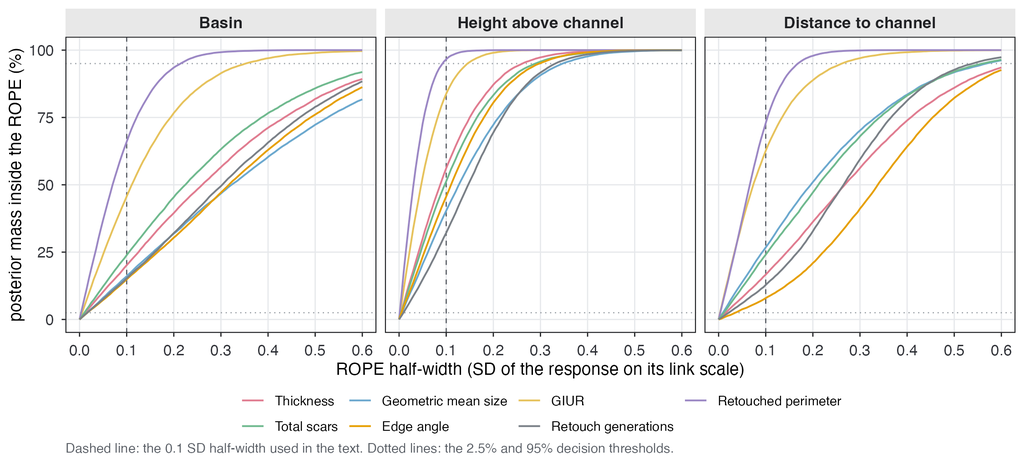

Figure 2: Posterior mass inside the ROPE as a function of the ROPE half-width, in link-scale SD units, for all 21 slopes. Dashed vertical line: the 0.1 half-width quoted in the text. Dotted horizontals: the 2.5% and 95% thresholds of the decision rule. A curve that has not reached 95% by a half-width the reader considers archaeologically negligible is a slope this design cannot declare absent.

## 6.2 Q1: Is There Technological Variation Between Localities?

Yes, for 3 of the seven measures under the reference prior, and for 2 of them under every prior tried.

For 3 responses (Geometric mean size, Total scars, Thickness) the 95% interval for the locality share of link-scale variance lies entirely above 0.05, so the rule of Section 6.1 rejects the null value of a negligible locality effect. Their posterior medians are 0.29, 0.23, 0.22, meaning that between 22% and 29% of the link-scale variance in those measures sits between localities rather than within them. The remaining 4 are undecided: their intervals run from near zero to values that would be substantial, and our model design does not separate the two.

Table 9: Q1 decisions. The ROPE for the ICC is [0, 0.05]: a locality share of link-scale variance below 5% is treated as negligible. Unlike the slope ROPE this bound is one-sided and has a natural reading – 5% of variance is a share no archaeological argument would build on.

| Response | ICC median [95% ETI] | P(ICC > 0.05) | Decision |
| --- | --- | --- | --- |
| Geometric mean size | 0.293 [0.120, 0.519] | 0.999 | locality variation present |
| Thickness | 0.221 [0.059, 0.470] | 0.983 | locality variation present |
| Total scars | 0.230 [0.054, 0.494] | 0.979 | locality variation present |
| Edge angle | 0.143 [0.032, 0.368] | 0.933 | undecided |
| GIUR | 0.091 [0.003, 0.380] | 0.702 | undecided |
| Retouch generations | 0.093 [0.001, 0.370] | 0.696 | undecided |
| Retouched perimeter | 0.037 [0.000, 0.209] | 0.398 | undecided |

Q1 is the only part of the analysis that returns a decisive answer, and how far it survives the prior is set out in detail below (Table 27).

For Geometric mean size and Thickness the decision is ‘locality variation present’ under every one of the seven priors. For Total scars it is not: the 2.5% limit sits so close to the 0.05 bound that S3 pushes it just below, and the verdict becomes undecided (2.5% limit 0.048 under S3, against 0.054 under the reference). The median barely moves (0.218 against 0.230), so the decision turns on a boundary rather than on a change in the estimate.

The safe reading is therefore the narrower one: **2 of the seven measures show between-locality variation that no prior in the sensitivity set can explain away**, and Total scars sits on the boundary.

The `noland` fit tests directly whether the landscape terms produce the between-locality variation (Section 5). It drops those three terms and keeps the locality intercept. If basin, elevation and distance supplied the between-locality signal, removing them would inflate the locality variance component; equivalently, adding them to the intercept-only model would deflate it. The comparison avoids the wide intervals on the individual slopes altogether.

Table 10: The ICC with and without the three landscape terms. A large negative change would mean the landscape terms had absorbed between-locality variance; a change near zero means they explain almost none of it.

| Response | intercept only | with landscape terms | change in the median | as a share of the intercept-only median |
| --- | --- | --- | --- | --- |
| Thickness | 0.188 [0.051, 0.416] | 0.221 [0.059, 0.470] | 0.033 | 0.173 |
| Geometric mean size | 0.259 [0.095, 0.482] | 0.293 [0.120, 0.519] | 0.034 | 0.130 |
| GIUR | 0.043 [0.000, 0.240] | 0.091 [0.003, 0.380] | 0.048 | 1.101 |
| Retouched perimeter | 0.034 [0.000, 0.167] | 0.037 [0.000, 0.209] | 0.003 | 0.089 |
| Total scars | 0.198 [0.044, 0.437] | 0.230 [0.054, 0.494] | 0.032 | 0.162 |
| Edge angle | 0.160 [0.051, 0.357] | 0.143 [0.032, 0.368] | -0.017 | -0.105 |
| Retouch generations | 0.126 [0.012, 0.375] | 0.093 [0.001, 0.370] | -0.033 | -0.261 |

The three landscape terms absorb none of the between-locality variance. If they explained it, the locality share would fall when they enter the model, and it does not fall: the median change across the seven responses is +13.0% of the intercept-only value, 5 of the seven go up and 2 go down, and the individual changes run from -26% (Retouch generations) to +110% (GIUR), the largest of which starts from an intercept-only median of only 0.043, so that ratio is unstable rather than meaningful. The pattern is noise scattered about zero. This is direct evidence on Q2, and it survives however poorly any single coefficient is resolved: whatever separates the localities, these three landscape variables are not it.

## 6.3 Q2: Do the Landscape Variables Explain It?

The analysis identifies no landscape variable that matters to the stone artefacts, and for most of them it also cannot establish that they do not.

Of the 21 slopes, at the 0.1 SD ROPE: 0 reject the null value, 1 accept it, and 20 are undecided. The intervals are too wide for the ROPE. That is what a design delivers when 26 localities supply every predictor and one binary contrast represents basin (Section 3.2). Table 22 gives each of the 21 decisions beside the estimate, the interval and the ROPE mass it rests on.

No slope in Panel B is prior-dominated: the largest posterior/prior SD ratio over all 21 is 0.34, so every point in the panel is an estimate the data have shaped.

What our analysis can state positively is confined to a single slope: Retouched perimeter with height above channel (z) (0.00 [-0.09, 0.09] on the standardised axis, 97.0% of the posterior inside the ROPE).

Direction certainty tells the same story from the other side. The largest value over all 21 slopes is 0.969 (Edge angle ~ Distance to channel (z)); a value of 0.5 would mean the posterior is split evenly about zero. Nothing here approaches the near-certainty of sign that would be needed to claim a directional landscape effect.

### 6.3.1 What This Design Could Have Decided: the Smallest Acceptable ROPE

For each slope there is a smallest ROPE half-width at which the 95% interval would have fitted entirely inside, namely $\max(|\text{lower}|, |\text{upper}|)$. Anything wider than that, this design *can* declare practically zero; anything narrower, it cannot. Translating that bound into the response’s own units turns “we could not decide” into a quantitative statement of what the study was able to rule out. The last column of Table 22 gives that bound for every slope, in the response’s own units: an effect smaller than it is what the study can rule out, an effect larger than it is what the study cannot.

The slopes with a *small* minimum acceptable ROPE are where the “undecided” label most misleads. For the three best-resolved slopes the 95% interval sits within 0.20 SD, so the analysis declines to call them zero at a tenth of an SD while still ruling out anything larger than the following: Retouched perimeter with height above channel (z), +/- 15 % in the odds; GIUR with height above channel (z), +/- 37 % in the odds; Retouched perimeter with distance to channel (z), +/- 35 % in the odds. That is a real, if modest, constraint. At the other extreme, Geometric mean size ~ Basin (Huangping vs Binchuan); Edge angle ~ Basin (Huangping vs Binchuan); Thickness ~ Basin (Huangping vs Binchuan) are effectively uninformative: their intervals span 1.0 SD or more, and no bound a reader would accept as negligible lies inside them.

## 6.4 Are the Landscape Effects the Same in Both Basins?

Cf. BARG Step 5. A structural extension rather than a prior change.

Section 6.3 asks whether the landscape explains the differences between localities and answers no. The obvious follow-up is whether that “no” is uniform, or whether it averages over two basins that behave differently.

The localities cannot answer it. All three predictors are locality attributes, so a slope that varies by locality is unidentified: within a locality the predictor never moves, and $a_j + b_j x_j$ collapses to a single number however many specimens that locality contributes (Section 3.2). The basin is the finest level at which the question can be put, because height and distance do vary across the localities inside each basin.

Binchuan’s 21 localities span 25–187 m above the channel and Huangping’s 5 span 35–69 m, so there is a gradient inside each basin to fit a slope to.

`ref_basinx` therefore replaces the two shared gradient slopes with one of each per basin, writing `Basin * zHeight + Basin * zDistance` and leaving the reference model otherwise untouched. With two basins this is a fixed contrast rather than a random slope, since two groups supply no variance to estimate. Binchuan is the reference level of the factor, so the interaction coefficient gives the Huangping slope minus the Binchuan one, and the Huangping slope itself forms draw by draw as their sum.

### 6.4.1 The Difference Between the Two Basins

Table 11: The 14 basin contrasts: the Huangping gradient slope minus the Binchuan one, standardised by the link-scale SD of the response so that the ROPE is the same band used everywhere else in this report.

| Response | Gradient | std median | 2.5% | 97.5% | % in ROPE | Verdict |
| --- | --- | --- | --- | --- | --- | --- |
| Total scars | Height | 0.966 | 0.039 | 1.659 | 1.670 | reject the null value |
| Edge angle | Height | 0.572 | -0.345 | 1.293 | 7.145 | undecided |
| Retouch generations | Height | 0.508 | -0.288 | 1.193 | 7.310 | undecided |
| Geometric mean size | Height | 0.424 | -0.679 | 1.461 | 10.730 | undecided |
| Total scars | Distance | 0.413 | -0.416 | 1.205 | 11.555 | undecided |
| Retouch generations | Distance | 0.289 | -0.450 | 1.027 | 15.525 | undecided |
| GIUR | Distance | 0.270 | -0.319 | 0.795 | 16.855 | undecided |
| Thickness | Height | 0.265 | -0.801 | 1.219 | 13.855 | undecided |
| Thickness | Distance | -0.253 | -1.109 | 0.594 | 15.390 | undecided |
| Geometric mean size | Distance | -0.241 | -1.120 | 0.633 | 15.985 | undecided |
| GIUR | Height | 0.218 | -0.456 | 0.782 | 18.710 | undecided |
| Edge angle | Distance | 0.175 | -0.575 | 0.914 | 18.920 | undecided |
| Retouched perimeter | Height | 0.164 | -0.199 | 0.480 | 27.895 | undecided |
| Retouched perimeter | Distance | 0.007 | -0.381 | 0.378 | 40.030 | undecided |

Of the 14 contrasts, 1 clears the ROPE and 13 are undecided. The one that clears it is Total scars with height with the gradient, and its interval reaches 0.04 at the near end. One result out of 14 comparisons, with a limit that close to zero, is what chance produces. Taken one at a time, then, the contrasts do not establish that the basins differ.

### 6.4.2 The Two Basins’ Slopes Side by Side

The contrasts give only part of the picture, because a difference can be undecided while the two slopes it separates look nothing alike. Binchuan’s slopes are estimated from its 21 localities and Huangping’s from its 5, on the same standardised axis as the contrasts above.

The pattern is one-sided. 8 of the 14 Binchuan slopes are positive and 6 negative, scattered about zero, and 0 have an interval excluding zero. All 14 Huangping slopes are positive, and 4 have an interval excluding zero. So we have a landscape signal in one basin and none in the other.

That said, a closer look suggest it is best to read this as a directional hint rather than a firm finding. The Huangping intervals are 2.1 times as wide as Binchuan’s, so correspondingly less information sits behind the larger medians; a big point estimate with a wide interval is what a small sample looks like. The intervals that exclude zero do so by a margin of 0.02 at the near end. The consistency of sign is also weaker evidence than it appears: the posterior probability that all 7 Huangping height slopes are *simultaneously* positive is **33%**, well short of the near certainty that 14 positive medians might suggest.

## 6.5 How Far the Conclusions Depend on the Prior

Six fits differ from the reference in exactly one prior each. Appendix F (Section 13) reports every ICC and every slope under all seven.

Of the 28 quantities, **1** receives a different decision under at least one of the seven priors: ICC: Total scars. Those rows are the ones a reader should treat as prior-dependent; the rest are not. The largest movement of a posterior median across the seven priors, relative to the average width of that quantity’s own 95% interval, is **39.5%** of the interval width, for Edge angle ~ Distance to channel (z); for 24 of the 28 quantities the movement is under a tenth of the interval width.

## 6.6 What Our Bayesian Model Can and Cannot Resolve

The three limits set by our design itself are stated in Section 3.2: 26 localities rather than 165 specimens as the effective sample for Q2, one basin contrast, and assemblages of very unequal size. Three further limits arise from the model rather than from the sample.

1. The 21 correlations are weakly identified. Estimating a 7 x 7 correlation matrix from 26 clusters asks a great deal, so Figure 11 describes the fitted structure rather than reporting a set of findings. S5 shows how much the LKJ concentration moves them.
2. The `sd` prior is unscaled across responses, and the results show where that matters. The reference `student_t(3, 0, 2)` on the locality SD keeps one scale for all seven responses, unlike the slope prior (Section 4.5). For edge angle, measured in degrees with a link-scale SD of 8.1, a prior of scale 2 is restrictive; for log thickness, whose link-scale SD is 0.30, the same prior is extremely loose. The sensitivity analysis shows the consequence in the numbers. The edge-angle ICC is 0.143 [0.032, 0.368] under the reference prior and 0.063 [0.007, 0.163] under S4, the largest prior-driven movement of any ICC in the set, and it happens to the response whose measurement scale is furthest from the prior’s. S4 replaces the heavy-tailed half-$t$ with a prior whose tail dies quickly, which on a scale measured in degrees is a strong statement. The refinement this calls for is the one already applied to the slopes: scale the locality SD prior to each response’s own link-scale SD. That specification fell outside the one-at-a-time set fitted here, and it is the clearest open refinement of this model. Until someone makes it, the edge-angle ICC should be read as prior-sensitive. The measures behind the Q1 answer are far less exposed, because their link-scale SDs are small enough that `student_t(3, 0, 2)` is uninformative for them: Geometric mean size and Thickness keep the same decision under all seven priors while Total scars changes only because its 2.5% limit is already touching the bound.
3. Retouch generations are discrete and modelled as continuous (Section 11), and GMsize contains Thickness (Section 4.3) while the model assumes independent residuals across responses.

# 7 Reproducibility

Cf. BARG Step 6.

## 7.1 Install the Software

```
R                4.5.2 or later
CmdStan          2.39.0     (install with cmdstanr::install_cmdstan())
R packages       brms, cmdstanr, posterior, bayesplot, here, readxl,
                 dplyr, tidyr, ggplot2, patchwork, knitr, quarto (CLI)
```

The backend must be cmdstanr, and the CmdStan version above is part of the specification; the caption of Table 16 gives the reason.

## 7.2 Retrieve the Files

| File | What it is |
| --- | --- |
| `data/Quina_scraper_surface.xlsx` | specimen measurements, sheet “Quina scraper” |
| `data/Site_information.xlsx` | locality attributes: basin, height above channel, distance to channel |
| `paper/barg/barg_data.R` | builds the analysis frame; defines `link_sd`, the ROPE unit |
| `paper/barg/barg_priors.R` | all seven prior specifications, in full |
| `paper/barg/barg_models.R` | the eleven model specifications, the sampler call, the diagnostics |
| `paper/barg/barg_quantities.R` | every derived quantity: ICC, ROPE curves, HDI, MCSE, decisions |
| `paper/barg/barg_context.R` | assembles the environments the pipeline runs the above in |
| `paper/barg/barg_theme.R` | the figure style, copied from the manuscript pipeline |
| `paper/barg/barg_figures.R` | every figure |
| `paper/barg/barg_dummy_data.R` | the synthetic dataset described below |
| `paper/barg/barg_report.qmd` | this document |
| `_targets.R` | the pipeline: what depends on what, and what is rebuilt when |
| `_targets/` | the store, with the eleven fits and the pipeline metadata |
| `paper/barg/figures/*.png` | the figures written by `barg_figures.R`, at 300 dpi |

The scripts in that list produce every result in this document: `barg_quantities.R` the derived quantities, `barg_figures.R` the figures, and the code chunks of `barg_report.qmd` itself the tables, reading the stored fits. No result is transcribed by hand. Figure 4 is the one figure drawn inside the document rather than by `barg_figures.R`, for the reason given in Section 10.2. The tables that list rather than compute, such as the prior specification of Section 4.5 and the model series of Section 5, are written by hand and marked as such by having no code chunk. The rendered document omits the code; a reader who wants it goes to the archive.

`paper/_analysis.R` fits the same model for the two summary tables of the supplementary information, leaving the slope prior at `normal(0, 1)`, which is specification S1 of Section 13. None of the files above uses it, and none of them modifies it.

If the specimen data cannot be released, `paper/barg/barg_dummy_data.R` generates a synthetic dataset with the same columns, types, ranges, locality structure and missingness pattern as the real one, so that a reader can verify that the scripts run end to end without access to the measurements. It is simulated from the fitted model and reproduces no individual specimen.

## 7.3 Run the Analysis

```bash
Rscript -e "targets::tar_make()"
```

That command starts the pipeline that fits the eleven models, runs the 100 calibration refits of Section 10.5, derives the quantities, draws the figures and renders this document and the two manuscript documents, in dependency order.

Only the fitting is expensive, and it runs once. Every later `tar_make()` compares the stored hash of each target against its inputs and rebuilds only what has changed: edit a prior in `barg_priors.R` and the eleven fits are refitted; edit a figure in `barg_figures.R` and no fit is touched. The calibration refits are dealt into 10 branches, so an interrupted run resumes at the last completed branch, and they read the reference fit rather than the report context, so editing a figure cannot invalidate them either.

`targets::tar_visnetwork()` shows the graph and what in it is out of date, and `targets::tar_make(names = "fit_ref")` builds one target and its dependencies without touching the rest.

The eleven runs took between 1.5 and 4.9 minutes each on the machine that produced this document, a median of 4.5, all of them under R version 4.6.1 (2026-06-24 ucrt).

## 7.4 Session Information

```
CmdStan version: 2.39.0
```

```
Fits produced at: 2026-09-01 20:20:34 PDT
```

# 8 Appendix A. Priors in Full

Section 4.5 states the prior and the argument for scaling the slope prior to each response. This appendix gives the complete record: every row `prior_summary()` returns, the rows it still labels `default` and why the sampler never reaches them, the generated Stan prior block, and the brms defaults that the explicit specification replaced.

Table 12: prior_summary(fit_ref), every non-empty row.

| prior | class | coef | group | resp | dpar | lb | ub |
| --- | --- | --- | --- | --- | --- | --- | --- |
| normal(65, 20) | Intercept |  |  | EdgeAngle |  |  |  |
| normal(0, 1.5) | Intercept |  |  | GIUR |  |  |  |
| normal(3.7, 0.6) | Intercept |  |  | GMsize |  |  |  |
| normal(3, 1.0) | Intercept |  |  | NScar |  |  |  |
| normal(3, 2) | Intercept |  |  | RG |  |  |  |
| normal(0, 1.5) | Intercept |  |  | RLI |  |  |  |
| normal(3.2, 0.7) | Intercept |  |  | Thickness |  |  |  |
| lkj_corr_cholesky(1) | L |  |  |  |  |  |  |
| lkj_corr_cholesky(1) | L |  | Locality |  |  |  |  |
| normal(0, 8.072005) | b |  |  | EdgeAngle |  |  |  |
| normal(0, 1.973705) | b |  |  | GIUR |  |  |  |
| normal(0, 0.227985) | b |  |  | GMsize |  |  |  |
| normal(0, 0.563059) | b |  |  | NScar |  |  |  |
| normal(0, 0.656843) | b |  |  | RG |  |  |  |
| normal(0, 1.529982) | b |  |  | RLI |  |  |  |
| normal(0, 0.296954) | b |  |  | Thickness |  |  |  |
| beta(1, 1) | coi |  |  | GIUR |  | 0 | 1 |
| beta(1, 1) | coi |  |  | RLI |  | 0 | 1 |
| gamma(2, 0.1) | phi |  |  | GIUR |  | 0 |  |
| gamma(2, 0.1) | phi |  |  | RLI |  | 0 |  |
| student_t(3, 0, 6.4) | sd |  |  | EdgeAngle |  | 0 |  |
| student_t(3, 0, 2) | sd |  | Locality | EdgeAngle |  |  |  |
| student_t(3, 0, 2.5) | sd |  |  | GIUR |  | 0 |  |
| student_t(3, 0, 2) | sd |  | Locality | GIUR |  |  |  |
| student_t(3, 0, 2.5) | sd |  |  | GMsize |  | 0 |  |
| student_t(3, 0, 2) | sd |  | Locality | GMsize |  |  |  |
| student_t(3, 0, 2.5) | sd |  |  | NScar |  | 0 |  |
| student_t(3, 0, 2) | sd |  | Locality | NScar |  |  |  |
| student_t(3, 0, 2.5) | sd |  |  | RG |  | 0 |  |
| student_t(3, 0, 2) | sd |  | Locality | RG |  |  |  |
| student_t(3, 0, 2.5) | sd |  |  | RLI |  | 0 |  |
| student_t(3, 0, 2) | sd |  | Locality | RLI |  |  |  |
| student_t(3, 0, 2.5) | sd |  |  | Thickness |  | 0 |  |
| student_t(3, 0, 2) | sd |  | Locality | Thickness |  |  |  |
| gamma(2, 0.1) | shape |  |  | NScar |  | 0 |  |
| student_t(3, 0, 8.072005) | sigma |  |  | EdgeAngle |  | 0 |  |
| student_t(3, 0, 0.227985) | sigma |  |  | GMsize |  | 0 |  |
| student_t(3, 0, 0.656843) | sigma |  |  | RG |  | 0 |  |
| student_t(3, 0, 0.296954) | sigma |  |  | Thickness |  | 0 |  |
| beta(1, 1) | zoi |  |  | GIUR |  | 0 | 1 |
| beta(1, 1) | zoi |  |  | RLI |  | 0 | 1 |

28 further rows have an empty `prior` field. Every one of them names a specific `coef` and inherits the prior of its class; they are omitted above. Rows that specify no `coef` and are still empty, meaning genuinely flat priors, number 0. That is the condition `sample_prior = "only"` imposes, and it is why the prior predictive draws of Section 9 exist at all: with a flat prior anywhere, brms cannot sample from the prior. The prior predictive fit ran, so the condition is met.

33 of the 41 non-empty rows are marked `user`. The remaining 8 are marked `default`, which needs explaining:

Table 13: The rows prior_summary() still labels ‘default’.

| class | resp | group | prior |
| --- | --- | --- | --- |
| L |  |  | lkj_corr_cholesky(1) |
| sd | EdgeAngle |  | student_t(3, 0, 6.4) |
| sd | GIUR |  | student_t(3, 0, 2.5) |
| sd | GMsize |  | student_t(3, 0, 2.5) |
| sd | NScar |  | student_t(3, 0, 2.5) |
| sd | RG |  | student_t(3, 0, 2.5) |
| sd | RLI |  | student_t(3, 0, 2.5) |
| sd | Thickness |  | student_t(3, 0, 2.5) |

They are not priors the sampler uses. The `sd` rows name no `group`: they sit one level above the `sd` + `Locality` rows that were set explicitly, and brms takes the most specific match, so these parents are never reached. The `L` row is brms’s own restatement of the user-supplied `lkj(1)` in the Cholesky parameterisation it actually samples in.

The authoritative record is the generated Stan program rather than `prior_summary()`. Its prior block, extracted verbatim, is the complete list of what was added to the log posterior:

```
lprior += normal_lpdf(b_Thickness | 0, 0.296954);
lprior += normal_lpdf(Intercept_Thickness | 3.2, 0.7);
lprior += student_t_lpdf(sigma_Thickness | 3, 0, 0.296954)
- 1 * student_t_lccdf(0 | 3, 0, 0.296954);
lprior += normal_lpdf(b_GMsize | 0, 0.227985);
lprior += normal_lpdf(Intercept_GMsize | 3.7, 0.6);
lprior += student_t_lpdf(sigma_GMsize | 3, 0, 0.227985)
- 1 * student_t_lccdf(0 | 3, 0, 0.227985);
lprior += normal_lpdf(b_GIUR | 0, 1.973705);
lprior += normal_lpdf(Intercept_GIUR | 0, 1.5);
lprior += gamma_lpdf(phi_GIUR | 2, 0.1);
lprior += beta_lpdf(zoi_GIUR | 1, 1);
lprior += beta_lpdf(coi_GIUR | 1, 1);
lprior += normal_lpdf(b_RLI | 0, 1.529982);
lprior += normal_lpdf(Intercept_RLI | 0, 1.5);
lprior += gamma_lpdf(phi_RLI | 2, 0.1);
lprior += beta_lpdf(zoi_RLI | 1, 1);
lprior += beta_lpdf(coi_RLI | 1, 1);
lprior += normal_lpdf(b_NScar | 0, 0.563059);
lprior += normal_lpdf(Intercept_NScar | 3, 1.0);
lprior += gamma_lpdf(shape_NScar | 2, 0.1);
lprior += normal_lpdf(b_EdgeAngle | 0, 8.072005);
lprior += normal_lpdf(Intercept_EdgeAngle | 65, 20);
lprior += student_t_lpdf(sigma_EdgeAngle | 3, 0, 8.072005)
- 1 * student_t_lccdf(0 | 3, 0, 8.072005);
lprior += normal_lpdf(b_RG | 0, 0.656843);
lprior += normal_lpdf(Intercept_RG | 3, 2);
lprior += student_t_lpdf(sigma_RG | 3, 0, 0.656843)
- 1 * student_t_lccdf(0 | 3, 0, 0.656843);
lprior += student_t_lpdf(sd_1 | 3, 0, 2)
- 7 * student_t_lccdf(0 | 3, 0, 2);
lprior += lkj_corr_cholesky_lpdf(L_1 | 1);
```

## 8.1 What the brms Defaults Would Have Been

Leaving a class at its default means inheriting a prior without reporting it, and two of the defaults here are read off the data rather than set independently of it. They are listed so that the cost of the explicit specification in Section 4.5 is visible.

Table 14: The brms defaults for every class other than b and sd. None of them is used by the reference fit; each was replaced by an explicit prior. The Intercept and sigma rows are read off the data, which would make them empirical priors rather than the vague priors a reader would assume.

| Class | Response | Group | brms default | Comment |
| --- | --- | --- | --- | --- |
| cor | – | – | lkj(1) | the 7 x 7 LKJ prior |
| Intercept | Edge angle | – | student_t(3, 70, 6.4) | data-dependent: centred and scaled on the observed response |
| sigma | Edge angle | – | student_t(3, 0, 6.4) | half-t scaled on the observed response |
| coi | GIUR | – | beta(1, 1) | uniform on (0, 1); proper, but unstated |
| Intercept | GIUR | – | student_t(3, 0, 2.5) | data-dependent: centred and scaled on the observed response |
| phi | GIUR | – | gamma(0.01, 0.01) | near-improper; mass arbitrarily close to zero |
| zoi | GIUR | – | beta(1, 1) | uniform on (0, 1); proper, but unstated |
| Intercept | Geometric mean size | – | student_t(3, 3.7, 2.5) | data-dependent: centred and scaled on the observed response |
| sigma | Geometric mean size | – | student_t(3, 0, 2.5) | half-t scaled on the observed response |
| Intercept | Total scars | – | student_t(3, 3, 2.5) | data-dependent: centred and scaled on the observed response |
| shape | Total scars | – | inv_gamma(0.4, 0.3) | very heavy right tail |
| Intercept | Retouch generations | – | student_t(3, 3, 2.5) | data-dependent: centred and scaled on the observed response |
| sigma | Retouch generations | – | student_t(3, 0, 2.5) | half-t scaled on the observed response |
| coi | Retouched perimeter | – | beta(1, 1) | uniform on (0, 1); proper, but unstated |
| Intercept | Retouched perimeter | – | student_t(3, 0, 2.5) | data-dependent: centred and scaled on the observed response |
| phi | Retouched perimeter | – | gamma(0.01, 0.01) | near-improper; mass arbitrarily close to zero |
| zoi | Retouched perimeter | – | beta(1, 1) | uniform on (0, 1); proper, but unstated |
| Intercept | Thickness | – | student_t(3, 3.2, 2.5) | data-dependent: centred and scaled on the observed response |
| sigma | Thickness | – | student_t(3, 0, 2.5) | half-t scaled on the observed response |

# 9 Appendix B. Prior Predictive Check

Cf. BARG Step 1.E.

The reference prior was refitted with `sample_prior = "only"`, so the draws below come from the prior alone with the data unseen. The question is not whether the simulated data look like the observed data. They should not; if they did, the prior would be doing the data’s work. The question is whether they are physically possible: no negative thicknesses, edge angles inside the range a goniometer can return, GIUR inside its definitional bounds, scar counts within reach of a single flake.

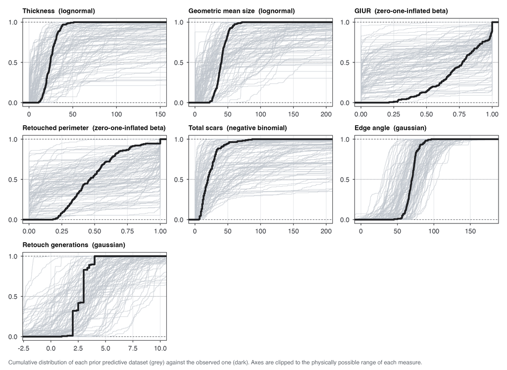

Figure 3: Prior predictive distributions (grey) against the observed distribution (dark), one panel per response. Axes are clipped to the physically possible range of each measure; the table below reports what falls outside.

Table 15: Prior predictive draws against the physically possible range of each measure. GIUR and the retouched perimeter cannot leave [0, 1] under the zero-one-inflated beta, so their zero is structural.

| Response | physically possible range | prior-predictive median | prior-predictive 2.5% | prior-predictive 97.5% | % outside the possible range |
| --- | --- | --- | --- | --- | --- |
| Thickness | 0 - 150 | 24.26 | 0.10 | 9765.97 | 17.57 |
| Geometric mean size | 0 - 250 | 41.82 | 0.05 | 11260.16 | 16.48 |
| GIUR | 0 - 1 | 0.45 | 0.00 | 1.00 | 0.00 |
| Retouched perimeter | 0 - 1 | 0.46 | 0.00 | 1.00 | 0.00 |
| Total scars | 0 - 400 | 19.00 | 0.00 | 64723.58 | 11.34 |
| Edge angle | 0 - 180 | 65.35 | 11.48 | 118.72 | 1.32 |
| Retouch generations | 0 - 12 | 3.00 | -4.99 | 11.06 | 20.14 |

# 10 Appendix C. Computation, Convergence and Resolution

## 10.1 Software and Settings

Cf. BARG Step 2.A.

Table 16: Computational settings. Chains, iterations, warmup, seed, sampler settings, brms and CmdStan are identical for all eleven runs, as is the R version the R row names. The backend is locked to cmdstanr: an rstan fit of the same model is not bit-for-bit reproducible against a cmdstanr fit, and the CmdStan version pins the C++ that sessionInfo() does not capture.

| Item | Value |
| --- | --- |
| R | R version 4.6.1 (2026-06-24 ucrt) |
| brms | 2.23.0 |
| Stan backend | cmdstanr |
| CmdStan | 2.39.0 |
| posterior | 1.7.0 |
| chains | 4 |
| iterations per chain | 10000 |
| warmup per chain | 5000 |
| post-warmup draws | 20,000 |
| seed | 2226 |
| adapt_delta | 0.8 (default) |
| max_treedepth | 10 (default) |

Every estimate, interval and decision in this report comes from the full run recorded above: 4 chains of 10,000 iterations and 20,000 post-warmup draws, rather than from a reduced pipeline test. The one set of numbers drawn from shorter runs is the calibration check of Section 10.5, whose 100 refits use 4 chains of 2,000 because a rank needs far fewer draws than a three-decimal quantile. Those refits also compile the Stan program afresh under cmdstanr 0.9.0, rather than reusing the one stored in the reference fit, which was built under a version whose interface has since changed; the brms and CmdStan versions that write and run that program are the ones in the table above.

## 10.2 Chain Convergence

Cf. BARG Step 2.B.

For the reference fit: divergent transitions **0**, iterations at maximum treedepth **0**, largest $\hat R$ over all 256 estimated parameters **1.0013**.

The conclusions rest on more than the reference fit: the intercept-only model supplies the Q1 comparison and the prior variants supply the sensitivity analysis. The same diagnostics therefore appear for all eleven runs.

Table 17: Diagnostics for all eleven runs, each of 20,000 post-warmup draws.

| Fit | parameters | max Rhat | min bulk ESS | min tail ESS | divergent transitions | at max treedepth |
| --- | --- | --- | --- | --- | --- | --- |
| ref | 256 | 1.0013 | 4255 | 4478 | 0 | 0 |
| prior_ref | 256 | 1.0010 | 9280 | 9833 | 0 | 0 |
| noland | 235 | 1.0007 | 6531 | 8380 | 4 | 0 |
| s1 | 256 | 1.0009 | 4462 | 2935 | 2 | 0 |
| s2 | 256 | 1.0013 | 4362 | 4242 | 0 | 0 |
| s3 | 256 | 1.0010 | 4457 | 4793 | 1 | 0 |
| s4 | 256 | 1.0011 | 4805 | 4135 | 1 | 0 |
| s5 | 256 | 1.0009 | 4807 | 4733 | 0 | 0 |
| s6 | 254 | 1.0011 | 4700 | 5480 | 0 | 0 |
| ref_rg_ln | 256 | 1.0012 | 5173 | 5449 | 1 | 0 |
| ref_basinx | 270 | 1.0010 | 5401 | 7066 | 0 | 0 |

5 of the eleven runs produced a small number of divergent transitions (noland: 4, s1: 2, s3: 1, s4: 1, ref_rg_ln: 1) against 20,000 draws each, which is at most 0.020% of the transitions in any run. Two observations bear on how much weight to put on them: the affected runs’ Rhat and ESS are indistinguishable from the clean ones, and their posteriors coincide with the reference in Figure 13. The usual explanation for divergences at this rate in a hierarchical model with 26 clusters and a 7 x 7 correlation matrix is mild curvature in the posterior near zero variance, but this report has not located them in parameter space and so offers that as an inference rather than as a demonstration. All eleven runs are reported here in full.

Table 17 reduces each run to its worst value on each diagnostic, which is the right summary for deciding whether a run is usable and the wrong one for seeing how the chains behaved. Figure 4 shows the chains themselves for the reference fit. It uses rank plots rather than trace plots, on the argument of Vehtari, Gelman, Simpson, et al. (2021), who introduced the $\hat R$ this report quotes and proposed the rank plot alongside it: with 20,000 draws a trace plot is an unreadable band of ink, whereas ranking the draws across chains and counting each chain’s share of each rank bin stays legible at any chain length and exposes chains that differ in location or in scale.

The 9 quantities in the figure are chosen by a rule fixed in the code rather than by inspection. The seven ICCs are there because Q1 rests on them and because the smallest effective sample size anywhere in the analysis is one of them (Section 10.3). The rest are the sampled parameter with the lowest bulk ESS, the sampled parameter with the lowest tail ESS, and the log posterior density, which come to 2 panels because one parameter is worst on both counts. A reader expecting the figure to reveal a problem will be disappointed, which is its purpose: with $\hat R$ at 1.0013 and 0 divergent transitions the chains should look interchangeable, and the figure lets a reader confirm that instead of taking the summary on trust.

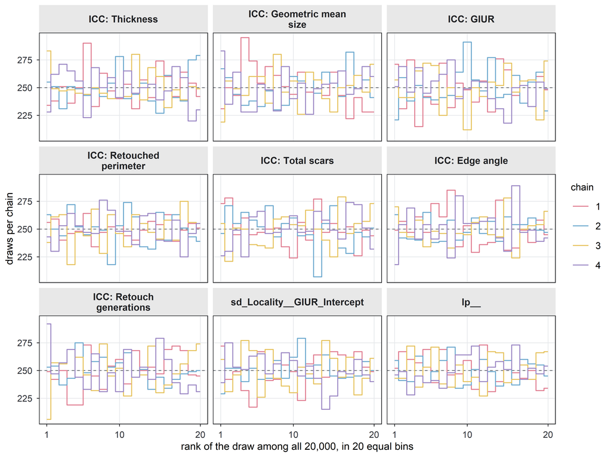

Figure 4: Rank plots for the reference fit. The draws of each quantity are pooled across the four chains and ranked; each line counts how many of one chain’s draws fall in each of 20 equal rank bins. Under convergence every chain contributes an equal share of every bin, so the four lines should be flat and overlapping around the dashed expected count. A chain running high at one end of the axis and low at the other has explored a different part of the distribution from the others. The seven ICCs are derived draw by draw and diagnosed exactly like sampled parameters; the remaining panels are the log posterior density and the sampled parameters with the lowest bulk and tail effective sample sizes.

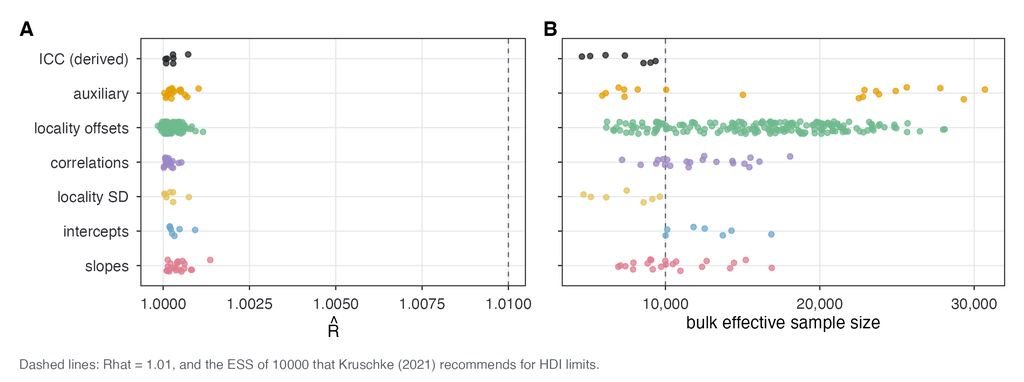

Figure 5: Rhat (A) and bulk effective sample size (B) for every estimated parameter, and for the seven ICCs, which are derived quantities computed draw by draw and diagnosed like any other.

## 10.3 Chain Resolution

Cf. BARG Step 2.C.

Kruschke (2021) suggests an ESS of about 10,000, with the explicit qualification that the figure aims at the stability of HDI limits and that quantile-based limits are less demanding. This report is quantile-based throughout (Section 12), so it gives both: the ESS, and the Monte Carlo standard error of each quantile it reports.

The table below prints the 60 quantities this report quotes or discusses. The 263 quantities of the full model also include 182 locality offsets and 21 locality-intercept correlations, which Figure 12 and Table 24 already give; printing them again here would bury the rows a reader needs in a table of 263. The summaries below the table are computed over all 263, and the archive contains the complete version.

Table 18: Convergence and resolution for the slopes, the intercepts, the auxiliary parameters and the locality SDs, and for the seven derived ICCs. Median and equal-tailed limits are given with their Monte Carlo standard errors; mode and HDI limits are given alongside, following the reference BARG document. The locality offsets and the locality-intercept correlations are left out of the printed table: Figure 12 draws the offsets, Table 24 gives the correlations with their own diagnostics, and the complete table is deposited with the archive (Section 7).

| Parameter | median | 2.5% | 97.5% | mode | HDI lo | HDI hi | MCSE 2.5% | MCSE median | MCSE 97.5% | Rhat | ESS bulk | ESS tail |
| --- | --- | --- | --- | --- | --- | --- | --- | --- | --- | --- | --- | --- |
| b_Thickness_Intercept | 3.2391 | 3.1055 | 3.3742 | 3.2275 | 3.1080 | 3.3762 | 0.0022 | 0.0009 | 0.0016 | 1.0003 | 10096 | 13339 |
| b_GMsize_Intercept | 3.7482 | 3.6417 | 3.8592 | 3.7506 | 3.6407 | 3.8579 | 0.0012 | 0.0007 | 0.0014 | 1.0003 | 10006 | 12787 |
| b_GIUR_Intercept | 0.9793 | 0.4427 | 1.4851 | 0.9797 | 0.4372 | 1.4775 | 0.0064 | 0.0029 | 0.0077 | 1.0001 | 10512 | 11279 |
| b_RLI_Intercept | -0.1057 | -0.3535 | 0.1466 | -0.1030 | -0.3514 | 0.1484 | 0.0032 | 0.0011 | 0.0031 | 1.0004 | 17041 | 14803 |
| b_NScar_Intercept | 3.1575 | 2.8954 | 3.4118 | 3.1635 | 2.8951 | 3.4108 | 0.0035 | 0.0011 | 0.0035 | 1.0000 | 11893 | 13466 |
| b_EdgeAngle_Intercept | 71.8347 | 68.6115 | 75.0553 | 71.7409 | 68.6868 | 75.1247 | 0.0469 | 0.0142 | 0.0362 | 1.0001 | 13737 | 14572 |
| b_RG_Intercept | 2.8778 | 2.6182 | 3.1329 | 2.8747 | 2.6182 | 3.1331 | 0.0035 | 0.0012 | 0.0032 | 1.0001 | 15597 | 12463 |
| b_Thickness_BasinHuangping | -0.0620 | -0.2410 | 0.1234 | -0.0562 | -0.2435 | 0.1205 | 0.0023 | 0.0012 | 0.0029 | 1.0006 | 6575 | 9706 |
| b_Thickness_zHeight | -0.0075 | -0.0852 | 0.0693 | -0.0056 | -0.0862 | 0.0681 | 0.0010 | 0.0004 | 0.0011 | 1.0001 | 9807 | 11931 |
| b_Thickness_zDistance | 0.0803 | -0.0428 | 0.2122 | 0.0731 | -0.0480 | 0.2065 | 0.0018 | 0.0009 | 0.0021 | 1.0002 | 6945 | 9931 |
| b_GMsize_BasinHuangping | -0.0681 | -0.2190 | 0.0863 | -0.0634 | -0.2182 | 0.0865 | 0.0022 | 0.0009 | 0.0024 | 1.0011 | 6508 | 9964 |
| b_GMsize_zHeight | -0.0264 | -0.0901 | 0.0346 | -0.0266 | -0.0891 | 0.0353 | 0.0010 | 0.0003 | 0.0005 | 1.0001 | 10658 | 12493 |
| b_GMsize_zDistance | 0.0370 | -0.0692 | 0.1459 | 0.0382 | -0.0711 | 0.1430 | 0.0014 | 0.0008 | 0.0016 | 1.0006 | 7154 | 9864 |
| b_GIUR_BasinHuangping | -0.0468 | -0.7601 | 0.6558 | 0.0014 | -0.7770 | 0.6309 | 0.0130 | 0.0041 | 0.0153 | 1.0002 | 7522 | 8716 |
| b_GIUR_zHeight | 0.0212 | -0.2609 | 0.3128 | 0.0224 | -0.2566 | 0.3165 | 0.0047 | 0.0012 | 0.0036 | 1.0004 | 10028 | 8923 |
| b_GIUR_zDistance | -0.0426 | -0.5971 | 0.3977 | -0.0165 | -0.5598 | 0.4328 | 0.0103 | 0.0027 | 0.0078 | 1.0009 | 7347 | 7466 |
| b_RLI_BasinHuangping | -0.0076 | -0.3397 | 0.3111 | -0.0009 | -0.3377 | 0.3129 | 0.0050 | 0.0017 | 0.0045 | 1.0002 | 11938 | 12680 |
| b_RLI_zHeight | 0.0035 | -0.1339 | 0.1419 | 0.0001 | -0.1342 | 0.1416 | 0.0015 | 0.0006 | 0.0018 | 1.0005 | 16433 | 13388 |
| b_RLI_zDistance | 0.0981 | -0.0902 | 0.3001 | 0.0861 | -0.0976 | 0.2914 | 0.0034 | 0.0009 | 0.0034 | 1.0004 | 10344 | 10870 |
| b_NScar_BasinHuangping | -0.0702 | -0.4198 | 0.2793 | -0.0579 | -0.4069 | 0.2907 | 0.0044 | 0.0020 | 0.0056 | 1.0004 | 8977 | 9731 |
| b_NScar_zHeight | 0.0373 | -0.1029 | 0.1848 | 0.0385 | -0.1037 | 0.1829 | 0.0011 | 0.0007 | 0.0019 | 1.0002 | 13350 | 13508 |
| b_NScar_zDistance | 0.1092 | -0.1512 | 0.3533 | 0.1139 | -0.1429 | 0.3605 | 0.0045 | 0.0013 | 0.0040 | 1.0003 | 9019 | 11058 |
| b_EdgeAngle_BasinHuangping | -2.5011 | -6.8593 | 1.7348 | -2.6068 | -6.9866 | 1.5754 | 0.0588 | 0.0228 | 0.0622 | 1.0001 | 10176 | 12074 |
| b_EdgeAngle_zHeight | 0.7915 | -0.9882 | 2.7039 | 0.8512 | -1.0456 | 2.6370 | 0.0225 | 0.0085 | 0.0261 | 1.0004 | 13080 | 12829 |
| b_EdgeAngle_zDistance | 2.7123 | -0.1988 | 5.6197 | 2.6742 | -0.0608 | 5.7408 | 0.0471 | 0.0153 | 0.0459 | 1.0001 | 8912 | 11420 |
| b_RG_BasinHuangping | -0.1910 | -0.5296 | 0.1438 | -0.1943 | -0.5157 | 0.1570 | 0.0046 | 0.0017 | 0.0047 | 1.0001 | 11111 | 11127 |
| b_RG_zHeight | 0.0965 | -0.0468 | 0.2432 | 0.0980 | -0.0499 | 0.2396 | 0.0016 | 0.0007 | 0.0015 | 1.0003 | 15431 | 13243 |
| b_RG_zDistance | 0.1734 | -0.0629 | 0.3915 | 0.1771 | -0.0522 | 0.4001 | 0.0044 | 0.0011 | 0.0037 | 1.0001 | 9639 | 10136 |
| sd_Locality__Thickness_Intercept | 0.1471 | 0.0714 | 0.2556 | 0.1403 | 0.0634 | 0.2454 | 0.0011 | 0.0005 | 0.0016 | 1.0002 | 7236 | 9151 |
| sd_Locality__GMsize_Intercept | 0.1320 | 0.0774 | 0.2115 | 0.1248 | 0.0724 | 0.2039 | 0.0006 | 0.0004 | 0.0014 | 1.0008 | 9434 | 12342 |
| sd_Locality__GIUR_Intercept | 0.4695 | 0.0891 | 1.0385 | 0.4293 | 0.0377 | 0.9590 | 0.0070 | 0.0036 | 0.0121 | 1.0011 | 4255 | 4478 |
| sd_Locality__RLI_Intercept | 0.1456 | 0.0113 | 0.3766 | 0.1306 | 0.0000 | 0.3295 | 0.0010 | 0.0011 | 0.0028 | 1.0003 | 6649 | 7149 |
| sd_Locality__NScar_Intercept | 0.2691 | 0.1213 | 0.4843 | 0.2623 | 0.1096 | 0.4677 | 0.0023 | 0.0010 | 0.0029 | 1.0005 | 8745 | 10177 |
| sd_Locality__EdgeAngle_Intercept | 3.0137 | 1.3870 | 5.5381 | 2.8056 | 1.2182 | 5.2755 | 0.0238 | 0.0109 | 0.0430 | 1.0001 | 9664 | 10864 |
| sd_Locality__RG_Intercept | 0.2029 | 0.0212 | 0.4785 | 0.1811 | 0.0000 | 0.4223 | 0.0018 | 0.0017 | 0.0045 | 1.0005 | 4959 | 5193 |
| sigma_Thickness | 0.2765 | 0.2477 | 0.3102 | 0.2770 | 0.2458 | 0.3080 | 0.0004 | 0.0001 | 0.0004 | 1.0000 | 20824 | 14344 |
| sigma_GMsize | 0.2050 | 0.1838 | 0.2308 | 0.2037 | 0.1825 | 0.2290 | 0.0002 | 0.0001 | 0.0003 | 1.0001 | 25427 | 13143 |
| sigma_EdgeAngle | 7.3778 | 6.6109 | 8.3213 | 7.3239 | 6.6021 | 8.3063 | 0.0068 | 0.0037 | 0.0093 | 1.0003 | 21225 | 14784 |
| sigma_RG | 0.6311 | 0.5671 | 0.7084 | 0.6277 | 0.5636 | 0.7037 | 0.0006 | 0.0003 | 0.0010 | 1.0000 | 21640 | 14267 |
| phi_GIUR | 3.6381 | 2.8728 | 4.5548 | 3.6569 | 2.8742 | 4.5559 | 0.0115 | 0.0038 | 0.0102 | 1.0002 | 14618 | 13583 |
| phi_RLI | 8.2978 | 6.6806 | 10.2053 | 8.0685 | 6.6610 | 10.1753 | 0.0183 | 0.0074 | 0.0245 | 1.0002 | 21879 | 15648 |
| zoi_GIUR | 0.1060 | 0.0650 | 0.1592 | 0.1023 | 0.0622 | 0.1553 | 0.0005 | 0.0002 | 0.0007 | 1.0001 | 27979 | 14846 |
| zoi_RLI | 0.0580 | 0.0295 | 0.1000 | 0.0540 | 0.0269 | 0.0959 | 0.0003 | 0.0001 | 0.0006 | 1.0001 | 28022 | 13019 |
| coi_GIUR | 0.9623 | 0.8159 | 0.9987 | 0.9900 | 0.8476 | 1.0000 | 0.0025 | 0.0004 | 0.0001 | 1.0000 | 21787 | 9326 |
| coi_RLI | 0.9315 | 0.6946 | 0.9970 | 0.9806 | 0.7441 | 1.0000 | 0.0038 | 0.0006 | 0.0002 | 1.0000 | 20775 | 9632 |
| shape_NScar | 4.2833 | 3.3183 | 5.5152 | 4.2172 | 3.2877 | 5.4685 | 0.0103 | 0.0047 | 0.0176 | 1.0003 | 21948 | 14584 |
| Intercept_Thickness | 3.1942 | 3.0804 | 3.3169 | 3.1951 | 3.0812 | 3.3173 | 0.0021 | 0.0008 | 0.0021 | 1.0003 | 5330 | 7946 |
| Intercept_GMsize | 3.6991 | 3.5985 | 3.8037 | 3.6935 | 3.6014 | 3.8064 | 0.0015 | 0.0008 | 0.0015 | 1.0006 | 5825 | 9099 |
| Intercept_GIUR | 0.9490 | 0.4622 | 1.3540 | 0.9597 | 0.4803 | 1.3681 | 0.0132 | 0.0023 | 0.0083 | 1.0005 | 6338 | 6388 |
| Intercept_RLI | -0.1135 | -0.2817 | 0.0601 | -0.1150 | -0.2926 | 0.0477 | 0.0023 | 0.0007 | 0.0032 | 1.0007 | 9462 | 9850 |
| Intercept_NScar | 3.1074 | 2.8769 | 3.3243 | 3.1018 | 2.8855 | 3.3323 | 0.0039 | 0.0013 | 0.0031 | 1.0004 | 6702 | 10203 |
| Intercept_EdgeAngle | 70.0219 | 67.4216 | 72.6731 | 70.0013 | 67.3957 | 72.6306 | 0.0449 | 0.0131 | 0.0527 | 1.0001 | 8150 | 10150 |
| Intercept_RG | 2.7415 | 2.5293 | 2.9442 | 2.7498 | 2.5380 | 2.9524 | 0.0038 | 0.0010 | 0.0047 | 1.0001 | 7838 | 8091 |
| ICC_Thickness | 0.2206 | 0.0594 | 0.4700 | 0.1886 | 0.0385 | 0.4394 | 0.0017 | 0.0014 | 0.0031 | 1.0002 | 7112 | 9191 |
| ICC_GMsize | 0.2928 | 0.1200 | 0.5190 | 0.2757 | 0.1140 | 0.5109 | 0.0020 | 0.0012 | 0.0030 | 1.0009 | 9403 | 12339 |
| ICC_GIUR | 0.0912 | 0.0032 | 0.3798 | 0.0296 | 0.0000 | 0.3230 | 0.0005 | 0.0014 | 0.0054 | 1.0012 | 4221 | 4571 |
| ICC_RLI | 0.0372 | 0.0002 | 0.2093 | 0.0060 | 0.0000 | 0.1674 | 0.0000 | 0.0006 | 0.0036 | 1.0003 | 6554 | 7043 |
| ICC_NScar | 0.2300 | 0.0538 | 0.4945 | 0.1905 | 0.0359 | 0.4680 | 0.0018 | 0.0014 | 0.0033 | 1.0006 | 8587 | 10146 |
| ICC_EdgeAngle | 0.1432 | 0.0318 | 0.3682 | 0.1165 | 0.0121 | 0.3295 | 0.0010 | 0.0009 | 0.0035 | 1.0001 | 9356 | 10840 |
| ICC_RG | 0.0935 | 0.0011 | 0.3699 | 0.0177 | 0.0000 | 0.3170 | 0.0002 | 0.0016 | 0.0041 | 1.0004 | 4953 | 5159 |

Smallest bulk ESS: **4,221** (ICC_GIUR); smallest tail ESS: **4,478**. 68 of the 263 quantities have a bulk ESS below Kruschke’s 10,000, so the recommendation is not met everywhere even at 20,000 draws. What matters for a quantile-based report is the Monte Carlo error of the quantiles themselves. The largest MCSE of a reported median, as a fraction of that parameter’s own posterior SD, is **0.0158** (ICC_RG), so the simulation noise in the numbers this report quotes is about **63 times smaller** than the posterior uncertainty it describes. Table 18 gives the per-parameter MCSEs for anyone who wants to check a particular one.

## 10.4 How Many Digits the Simulation Supports

Gelman, Vehtari, McElreath, et al. (2026, sec. 11.6) argue that the number of digits to report should follow from the Monte Carlo error and the posterior uncertainty rather than from a printing default, and they take two significant digits as the usual answer. Since the previous section has already computed the Monte Carlo standard error of every quantile this report quotes, the rule can be applied to this document rather than merely cited.

Each of the 263 quantities in the model has two ceilings. The simulation supports decimal places up to the point where the Monte Carlo standard error stays below half a unit in the last digit. The posterior supports decimal places up to two significant digits of its own standard deviation, beyond which further digits describe the width of a distribution the data have not resolved that finely. Across the 263 quantities the first ceiling runs from 1 to 3 decimal places with a median of 2; it is the binding one for 46 quantities, and the posterior’s own width binds first for the other 217.

The audit is unflattering to the tables. They print three decimal places by default and four in Table 18, while 253 of the 263 quantities support fewer than three. Trimming a shared `digits` argument would not fix it, because the ceiling varies from 1 to 3 across rows measured on three different link scales, so no single setting is right for all of them. The per-row answer is already in the table: the three MCSE columns beside every quantile say how far that row can be read, and they are printed for this reason. A reader comparing two numbers that differ only in the third decimal place should look at that row’s MCSE before treating the difference as real.

Where a single figure has to be chosen, two decimal places is what the rule endorses for a typical quantity here, and it is what the summaries in Section 1 and Table 26 use. Buying one further digit would mean halving the Monte Carlo error, which needs four times the iterations.

## 10.5 Calibration of the Posterior: Posterior SBC

Everything else in this appendix is evidence about the sampler; this section is the one check that speaks to the posterior itself. 100 parameter vectors were drawn from the reference posterior, each was used to simulate a complete set of the seven responses for the same design, and the model was refit conditioning on the observed and the simulated rows together (330 rows), so that the reference posterior serves as the prior of the check (Säilynoja, Schmitt, Bürkner and Vehtari 2026). If the model’s uncertainty is honest, the value that generated a dataset should be no likelier to sit near the middle of the posterior refitted to that dataset than near either edge: over many simulations its position should be spread evenly. `paper/barg/barg_sbc.R` carries the construction, the reason the posterior version of the check is used here rather than the classical one, and the arithmetic behind the band below.

The 28 quantities under test are the ones the two research questions rest on: the 21 landscape slopes behind Q2 and the 7 locality ICCs behind Q1. For each of them, Figure 6 plots how far the 100 observed positions depart from an even spread, across the whole range of positions at once. The shaded band is how far an evenly spread set of 100 positions would stray 95% of the time; it is wide because the curve is judged at every position simultaneously, rather than at one position picked in advance, and at 100 simulations it reaches ±0.135. No quantity leaves it. The largest departure over all 28 is 0.121, for Geometric mean size ~ Height above channel (z); if every posterior were honest, 1.4 of the 28 would still be expected to leave the band by chance alone.

Table 19 applies a chi-square test to the same positions, sorting them into 20 equal bins and comparing the counts with what an even spread would give. This catches a pile-up at both ends of the range, which the first measure can miss because such a pile-up leaves the middle of the curve close to where it belongs. No quantity fails it at the Bonferroni-corrected threshold of 0.0018, the 5% level divided by the 28 quantities tested at once.

Across the 100 refits the largest $\hat R$ is 1.011, the smallest bulk effective sample size 766, and 10 produced at least one divergent transition. Every refit is reported as it came: dropping those that had not converged would make a calibration failure look like a clean result.

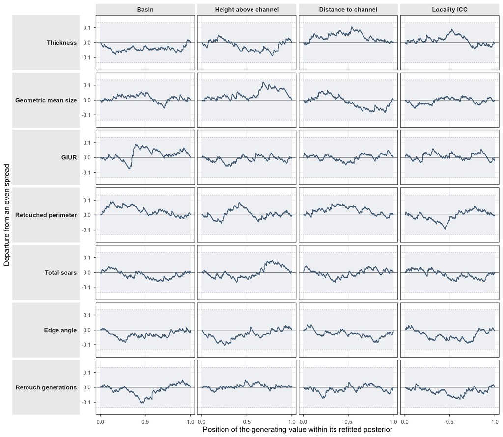

Figure 6: Posterior SBC. For each quantity, how far the observed positions of the generating values within their refitted posteriors depart from an even spread, plotted across the whole range of positions. The shaded band, dashed at its edge, is how far an even spread would stray 95% of the time when judged at every position at once. Three slope columns and one ICC column, one row per response, the same layout as Figure 1. A curve that stays inside the band is a quantity whose posterior covers its own generating value at the rate it claims; a curve drawn in colour leaves the band somewhere.

Table 19: Posterior SBC over 100 simulations, one row per quantity, ordered by how far its observed positions depart from an even spread. The band is the departure an even spread would stay within 95% of the time when the whole range of positions is judged at once; it is obtained by simulating even spreads over the same 201 possible positions the observed ones fall on, rather than from a large-sample formula, because the positions are discrete. The chi-square sorts the positions into 20 equal bins and compares the counts with what an even spread would give, on 19 degrees of freedom.

| Quantity | largest departure | 95% band | outside the band | chi-square | chi-square p |
| --- | --- | --- | --- | --- | --- |
| Geometric mean size ~ Height above channel (z) | 0.1209 | 0.1349 | no | 21.2 | 0.3259 |
| Edge angle ~ Height above channel (z) | 0.1062 | 0.1349 | no | 22.4 | 0.2648 |
| Retouch generations ~ Basin (Huangping vs Binchuan) | 0.1052 | 0.1349 | no | 19.2 | 0.4441 |
| Thickness ~ Distance to channel (z) | 0.1052 | 0.1349 | no | 16.8 | 0.6034 |
| Retouched perimeter ICC | 0.0953 | 0.1349 | no | 23.2 | 0.2286 |
| GIUR ~ Basin (Huangping vs Binchuan) | 0.0944 | 0.1349 | no | 38.8 | 0.0047 |
| Edge angle ICC | 0.0940 | 0.1349 | no | 19.2 | 0.4441 |
| Thickness ~ Height above channel (z) | 0.0936 | 0.1349 | no | 18.0 | 0.5224 |
| Retouched perimeter ~ Basin (Huangping vs Binchuan) | 0.0932 | 0.1349 | no | 17.6 | 0.5493 |
| Thickness ICC | 0.0901 | 0.1349 | no | 15.6 | 0.6838 |
| Retouched perimeter ~ Height above channel (z) | 0.0896 | 0.1349 | no | 18.4 | 0.4959 |
| Edge angle ~ Distance to channel (z) | 0.0886 | 0.1349 | no | 16.8 | 0.6034 |
| Geometric mean size ~ Distance to channel (z) | 0.0880 | 0.1349 | no | 25.2 | 0.1541 |
| Edge angle ~ Basin (Huangping vs Binchuan) | 0.0861 | 0.1349 | no | 15.2 | 0.7098 |
| Retouch generations ICC | 0.0844 | 0.1349 | no | 12.0 | 0.8856 |
| Thickness ~ Basin (Huangping vs Binchuan) | 0.0816 | 0.1349 | no | 14.4 | 0.7599 |
| Total scars ~ Height above channel (z) | 0.0814 | 0.1349 | no | 14.8 | 0.7352 |
| Retouched perimeter ~ Distance to channel (z) | 0.0797 | 0.1349 | no | 10.4 | 0.9424 |
| Retouch generations ~ Distance to channel (z) | 0.0764 | 0.1349 | no | 24.0 | 0.1962 |
| Total scars ~ Distance to channel (z) | 0.0657 | 0.1349 | no | 15.2 | 0.7098 |
| Total scars ICC | 0.0647 | 0.1349 | no | 13.2 | 0.8282 |
| Total scars ~ Basin (Huangping vs Binchuan) | 0.0643 | 0.1349 | no | 11.2 | 0.9169 |
| GIUR ICC | 0.0640 | 0.1349 | no | 20.0 | 0.3946 |
| GIUR ~ Height above channel (z) | 0.0611 | 0.1349 | no | 23.6 | 0.2119 |
| Geometric mean size ~ Basin (Huangping vs Binchuan) | 0.0598 | 0.1349 | no | 14.0 | 0.7837 |
| Geometric mean size ICC | 0.0570 | 0.1349 | no | 15.6 | 0.6838 |
| Retouch generations ~ Height above channel (z) | 0.0549 | 0.1349 | no | 14.8 | 0.7352 |
| GIUR ~ Distance to channel (z) | 0.0522 | 0.1349 | no | 17.2 | 0.5763 |

The check reaches the coded model and no further. Both limitations recorded in Section 6.6 — GMsize contains Thickness while the residuals are modelled as independent, and retouch generations is discrete — are inherited by the simulated datasets, so they lie outside this check rather than having passed it. What it does establish is that over the range of values the reference posterior occupies, each of the 28 quantities the two research questions turn on recovers its own generating value at the rate its intervals claim, to within the 0.135 this many simulations can resolve.

# 11 Appendix D. Posterior Predictive Checks

Cf. BARG Step 3.A. Kruschke (2021) treats this check as a precondition for reporting parameter estimates at all.

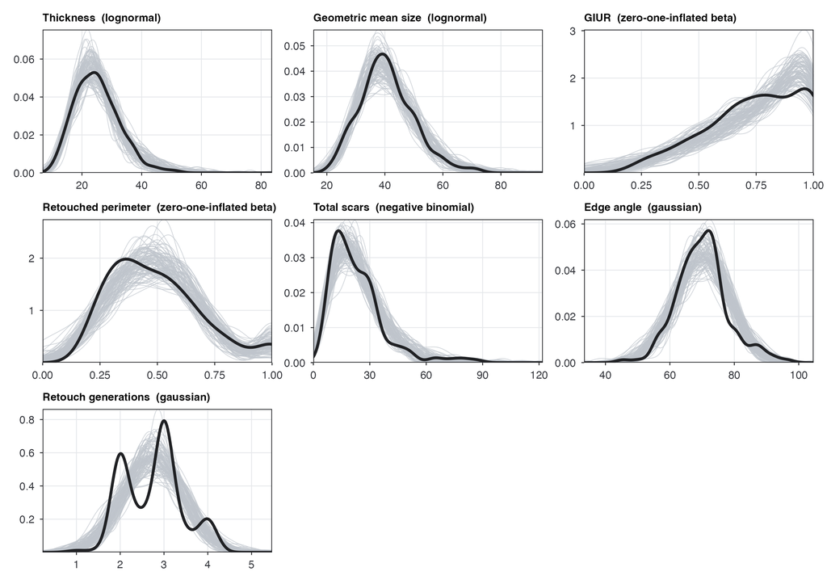

Figure 7: Posterior predictive distributions (grey, 100 draws) against the observed distribution (dark), one panel per response.

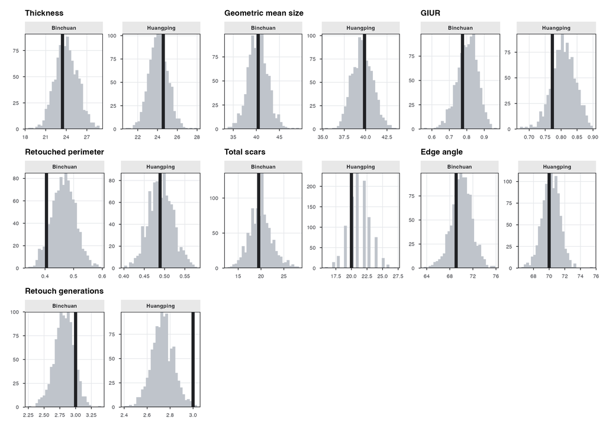

Figure 8: Posterior predictive check by basin: the observed median of each response within each basin, against the distribution of that same statistic in the replicated datasets.

## 11.1 The Checks That Were Specified in Advance

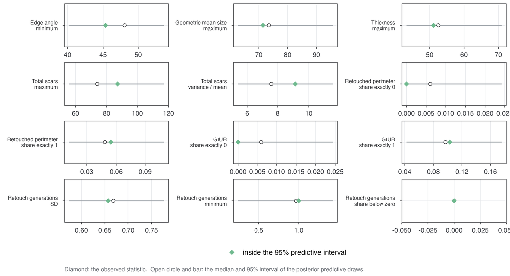

Figure 9: Targeted posterior predictive statistics. Diamond: the observed value. Open circle and bar: the median and 95% interval of the same statistic over the replicated datasets. Green means the observation falls inside the interval.

Table 20: Observed test statistics against their posterior predictive distributions.

| Response | Statistic | observed | replicated median | 2.5% | 97.5% | verdict |
| --- | --- | --- | --- | --- | --- | --- |
| Retouch generations | share below zero | 0.000 | 0.000 | 0.000 | 0.000 | reproduced |
| Retouch generations | minimum | 1.000 | 0.962 | 0.232 | 1.440 | reproduced |
| Retouch generations | SD | 0.657 | 0.672 | 0.581 | 0.788 | reproduced |
| GIUR | share exactly 1 | 0.103 | 0.103 | 0.042 | 0.170 | reproduced |
| GIUR | share exactly 0 | 0.000 | 0.000 | 0.000 | 0.024 | reproduced |
| Retouched perimeter | share exactly 1 | 0.055 | 0.048 | 0.012 | 0.109 | reproduced |
| Retouched perimeter | share exactly 0 | 0.000 | 0.000 | 0.000 | 0.030 | reproduced |
| Total scars | variance / mean | 9.133 | 7.587 | 5.457 | 11.236 | reproduced |
| Total scars | maximum | 87.000 | 74.000 | 55.000 | 109.025 | reproduced |
| Thickness | maximum | 51.120 | 52.313 | 42.881 | 73.497 | reproduced |
| Geometric mean size | maximum | 71.446 | 73.544 | 62.013 | 95.154 | reproduced |
| Edge angle | minimum | 45.333 | 47.890 | 39.973 | 53.877 | reproduced |

### 11.1.1 Does the Gaussian Likelihood for Retouch Generations Predict Negative Values?

The observed share of retouch-generation values below zero is 0.000; over the replicated datasets the share has median 0.000 and 95% interval [0.000, 0.000]. The observed minimum is 1.00 against a replicated interval of [0.23, 1.44]. The gaussian’s support extends below zero, while the fitted mean sits far enough above it relative to the residual SD that the model rarely generates impossible values in practice. The gaussian misses the *discreteness* instead: retouch generations are recorded as a small number of counted generations averaged over at most three edges, so the observed distribution is a spike train and the replicated one is smooth. Figure 7 shows it, and it is a real limitation of the family, though it leaves a location parameter unbiased.

The check is a judgement call rather than a pass or a failure, so the `ref_rg_ln` fit refits the same response as a lognormal for comparison (Section 5), letting a reader see directly whether the choice of family moves the conclusions:

Table 21: Retouch generations: the reference gaussian fit against a lognormal refit of the same response. Both are shown on their own standardised axis, so the ROPE is +/- 0.1 in each case.

| Family | Predictor | standardised median | 2.5% | 97.5% | % in ROPE | Verdict |
| --- | --- | --- | --- | --- | --- | --- |
| gaussian (reference) | Basin (Huangping vs Binchuan) | -0.291 | -0.806 | 0.219 | 16.155 | undecided |
| lognormal (comparison) | Basin (Huangping vs Binchuan) | -0.275 | -0.888 | 0.362 | 16.265 | undecided |
| gaussian (reference) | Distance to channel (z) | 0.264 | -0.096 | 0.596 | 13.070 | undecided |
| lognormal (comparison) | Distance to channel (z) | 0.266 | -0.195 | 0.692 | 15.580 | undecided |
| gaussian (reference) | Height above channel (z) | 0.147 | -0.071 | 0.370 | 31.970 | undecided |
| lognormal (comparison) | Height above channel (z) | 0.168 | -0.084 | 0.431 | 26.925 | undecided |

### 11.1.2 Do the Zero-One-Inflated Beta Fits Reproduce the Pile-Up at 1?

For GIUR the observed share of exact ones is 0.103 against a replicated interval of [0.042, 0.170]; for the retouched perimeter, 0.055 against [0.012, 0.109]. The share of exact zeros is 0 in the data and 0 in the replications. That agreement shows only that the zero-inflation half of the family is estimating a probability the data have pinned at essentially zero, and says nothing about whether the model captures zero inflation. See the note in Section 4.4.

### 11.1.3 Is the Overdispersion of the Scar Count Captured?

The observed variance-to-mean ratio is 9.13, well above the value of 1 a Poisson would imply; the replicated interval is [5.46, 11.24]. The negative binomial captures it.

# 12 Appendix E. Full Posterior Summaries

Cf. BARG Step 3.B.

Every interval in this report is a 95% equal-tailed (percentile) credible interval, running from the 2.5th to the 97.5th posterior percentile, and every point summary in the text is the posterior median. That is the quantile-based convention. The density-based pair, the posterior mode and the 95% highest-density interval, appears alongside it in Table 18 and Table 22, following the reference BARG document, so that a reader who prefers that pair need recompute nothing. Section 10.4 says how many of the printed decimal places the simulation supports.

Table 22: The 21 landscape slopes in full, each with the decision it supports beside the estimate, the interval and the ROPE mass that decision rests on. `median`, `2.5%`, `97.5%` are on the link scale; `std` columns divide by the link-scale SD of the response, which is the axis the 0.1 ROPE is defined on; `response scale` translates the median to a percentage change per unit of the predictor (log and logit links) or leaves it in the response’s own units (identity link). ‘Direction certainty’ is max(P(beta > 0), P(beta < 0)): 0.5 means the posterior is split evenly about zero, 1.0 that the sign is certain. The last column is the smallest ROPE half-width at which the 95% interval would have fitted entirely inside, in the response’s own units (Section 6.3.1).

| Response | Predictor | Link | median | 2.5% | 97.5% | mode | HDI lo | HDI hi | std median | std 2.5% | std 97.5% | % in ROPE | direction certainty | Decision | response scale [95% ETI] | unit | min ROPE, response scale |
| --- | --- | --- | --- | --- | --- | --- | --- | --- | --- | --- | --- | --- | --- | --- | --- | --- | --- |
| Thickness | Basin (Huangping vs Binchuan) | log | -0.062 | -0.241 | 0.123 | -0.056 | -0.243 | 0.121 | -0.209 | -0.812 | 0.416 | 20.3 | 0.756 | undecided | -6.0 [-21.4, 13.1] | % | +/- 27.3 % |
| Thickness | Height above channel (z) | log | -0.007 | -0.085 | 0.069 | -0.006 | -0.086 | 0.068 | -0.025 | -0.287 | 0.233 | 55.9 | 0.581 | undecided | -0.7 [-8.2, 7.2] | % | +/- 8.9 % |
| Thickness | Distance to channel (z) | log | 0.080 | -0.043 | 0.212 | 0.073 | -0.048 | 0.206 | 0.270 | -0.144 | 0.715 | 15.9 | 0.907 | undecided | 8.4 [-4.2, 23.6] | % | +/- 23.6 % |
| Geometric mean size | Basin (Huangping vs Binchuan) | log | -0.068 | -0.219 | 0.086 | -0.063 | -0.218 | 0.086 | -0.299 | -0.961 | 0.378 | 16.0 | 0.821 | undecided | -6.6 [-19.7, 9.0] | % | +/- 24.5 % |
| Geometric mean size | Height above channel (z) | log | -0.026 | -0.090 | 0.035 | -0.027 | -0.089 | 0.035 | -0.116 | -0.395 | 0.152 | 39.8 | 0.803 | undecided | -2.6 [-8.6, 3.5] | % | +/- 9.4 % |
| Geometric mean size | Distance to channel (z) | log | 0.037 | -0.069 | 0.146 | 0.038 | -0.071 | 0.143 | 0.162 | -0.303 | 0.640 | 26.7 | 0.763 | undecided | 3.8 [-6.7, 15.7] | % | +/- 15.7 % |
| GIUR | Basin (Huangping vs Binchuan) | logit | -0.047 | -0.760 | 0.656 | 0.001 | -0.777 | 0.631 | -0.024 | -0.385 | 0.332 | 45.8 | 0.558 | undecided | -4.6 [-53.2, 92.7] | % in the odds | +/- 113.9 % in the odds |
| GIUR | Height above channel (z) | logit | 0.021 | -0.261 | 0.313 | 0.022 | -0.257 | 0.317 | 0.011 | -0.132 | 0.158 | 83.5 | 0.561 | undecided | 2.1 [-23.0, 36.7] | % in the odds | +/- 36.7 % in the odds |
| GIUR | Distance to channel (z) | logit | -0.043 | -0.597 | 0.398 | -0.016 | -0.560 | 0.433 | -0.022 | -0.303 | 0.201 | 62.5 | 0.581 | undecided | -4.2 [-45.0, 48.8] | % in the odds | +/- 81.7 % in the odds |
| Retouched perimeter | Basin (Huangping vs Binchuan) | logit | -0.008 | -0.340 | 0.311 | -0.001 | -0.338 | 0.313 | -0.005 | -0.222 | 0.203 | 65.5 | 0.520 | undecided | -0.8 [-28.8, 36.5] | % in the odds | +/- 40.5 % in the odds |
| Retouched perimeter | Height above channel (z) | logit | 0.003 | -0.134 | 0.142 | 0.000 | -0.134 | 0.142 | 0.002 | -0.088 | 0.093 | 97.0 | 0.521 | accept the null value | 0.3 [-12.5, 15.3] | % in the odds | +/- 15.3 % in the odds |
| Retouched perimeter | Distance to channel (z) | logit | 0.098 | -0.090 | 0.300 | 0.086 | -0.098 | 0.291 | 0.064 | -0.059 | 0.196 | 71.9 | 0.865 | undecided | 10.3 [-8.6, 35.0] | % in the odds | +/- 35.0 % in the odds |
| Total scars | Basin (Huangping vs Binchuan) | log | -0.070 | -0.420 | 0.279 | -0.058 | -0.407 | 0.291 | -0.125 | -0.746 | 0.496 | 24.0 | 0.665 | undecided | -6.8 [-34.3, 32.2] | % | +/- 52.2 % |
| Total scars | Height above channel (z) | log | 0.037 | -0.103 | 0.185 | 0.038 | -0.104 | 0.183 | 0.066 | -0.183 | 0.328 | 51.1 | 0.701 | undecided | 3.8 [-9.8, 20.3] | % | +/- 20.3 % |
| Total scars | Distance to channel (z) | log | 0.109 | -0.151 | 0.353 | 0.114 | -0.143 | 0.361 | 0.194 | -0.268 | 0.627 | 23.3 | 0.818 | undecided | 11.5 [-14.0, 42.4] | % | +/- 42.4 % |
| Edge angle | Basin (Huangping vs Binchuan) | identity | -2.501 | -6.859 | 1.735 | -2.607 | -6.987 | 1.575 | -0.310 | -0.850 | 0.215 | 15.4 | 0.882 | undecided | -2.5 [-6.9, 1.7] | degrees | +/- 6.9 degrees |
| Edge angle | Height above channel (z) | identity | 0.792 | -0.988 | 2.704 | 0.851 | -1.046 | 2.637 | 0.098 | -0.122 | 0.335 | 46.8 | 0.808 | undecided | 0.8 [-1.0, 2.7] | degrees | +/- 2.7 degrees |
| Edge angle | Distance to channel (z) | identity | 2.712 | -0.199 | 5.620 | 2.674 | -0.061 | 5.741 | 0.336 | -0.025 | 0.696 | 8.1 | 0.969 | undecided | 2.7 [-0.2, 5.6] | degrees | +/- 5.6 degrees |
| Retouch generations | Basin (Huangping vs Binchuan) | identity | -0.191 | -0.530 | 0.144 | -0.194 | -0.516 | 0.157 | -0.291 | -0.806 | 0.219 | 16.2 | 0.874 | undecided | -0.2 [-0.5, 0.1] | generations | +/- 0.5 generations |
| Retouch generations | Height above channel (z) | identity | 0.096 | -0.047 | 0.243 | 0.098 | -0.050 | 0.240 | 0.147 | -0.071 | 0.370 | 32.0 | 0.909 | undecided | 0.1 [-0.0, 0.2] | generations | +/- 0.2 generations |
| Retouch generations | Distance to channel (z) | identity | 0.173 | -0.063 | 0.391 | 0.177 | -0.052 | 0.400 | 0.264 | -0.096 | 0.596 | 13.1 | 0.938 | undecided | 0.2 [-0.1, 0.4] | generations | +/- 0.4 generations |

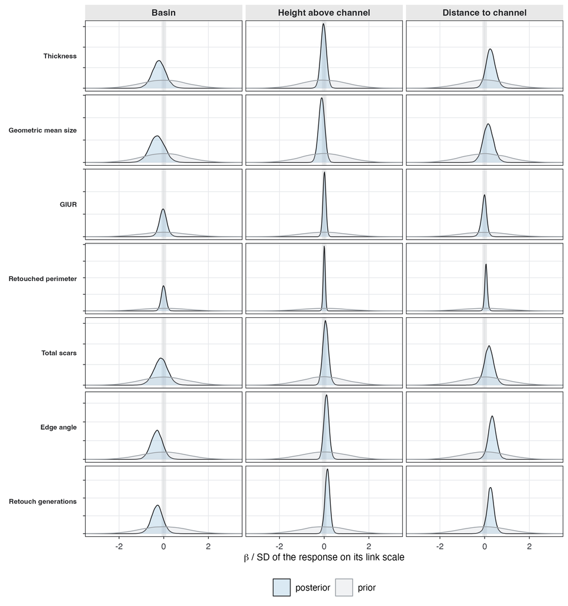

Figure 10: Prior (grey) against posterior (blue) for every slope, on the standardised axis. The shaded band is the ROPE. Where the two curves nearly coincide, the data have said little.

## 12.1 Locality-Level Variance and Correlation Structure

Cf. BARG Step 3.B, for the parameters that answer Q1.

The intraclass correlation is $\mathrm{ICC}^{(r)} = \sigma_u^{(r)2} / (\sigma_u^{(r)2} + \sigma_{\text{resid}}^{(r)2})$, computed **draw by draw** so that it acquires a full posterior. The residual variance is taken on the link scale, and its form depends on the family: $\sigma^2$ for the gaussian and lognormal responses; $\log(1 + 1/\mu + 1/\text{shape})$ evaluated at the intercept for the negative binomial; and, for the two zero-one-inflated beta responses, $\psi'(\mu\phi) + \psi'((1-\mu)\phi)$, the logit-scale variance of the beta component. For those two the ICC therefore describes the beta component alone and ignores the inflation (Section 4.4).

Table 23: Locality SD and intraclass correlation, with diagnostics for the derived quantity.

| Response | Family | locality SD | SD 2.5% | SD 97.5% | ICC median | 2.5% | 97.5% | ICC mode | HDI lo | HDI hi | P(ICC > 0.05) | Rhat | ESS bulk | Verdict |
| --- | --- | --- | --- | --- | --- | --- | --- | --- | --- | --- | --- | --- | --- | --- |
| Geometric mean size | lognormal | 0.132 | 0.077 | 0.211 | 0.293 | 0.120 | 0.519 | 0.276 | 0.114 | 0.511 | 0.999 | 1.001 | 9403 | locality variation present |
| Total scars | negative binomial | 0.269 | 0.121 | 0.484 | 0.230 | 0.054 | 0.494 | 0.191 | 0.036 | 0.468 | 0.979 | 1.001 | 8587 | locality variation present |
| Thickness | lognormal | 0.147 | 0.071 | 0.256 | 0.221 | 0.059 | 0.470 | 0.189 | 0.039 | 0.439 | 0.983 | 1.000 | 7112 | locality variation present |
| Edge angle | gaussian | 3.014 | 1.387 | 5.538 | 0.143 | 0.032 | 0.368 | 0.116 | 0.012 | 0.329 | 0.933 | 1.000 | 9356 | undecided |
| Retouch generations | gaussian | 0.203 | 0.021 | 0.478 | 0.093 | 0.001 | 0.370 | 0.018 | 0.000 | 0.317 | 0.696 | 1.000 | 4953 | undecided |
| GIUR | zero-one-inflated beta | 0.470 | 0.089 | 1.039 | 0.091 | 0.003 | 0.380 | 0.030 | 0.000 | 0.323 | 0.702 | 1.001 | 4221 | undecided |
| Retouched perimeter | zero-one-inflated beta | 0.146 | 0.011 | 0.377 | 0.037 | 0.000 | 0.209 | 0.006 | 0.000 | 0.167 | 0.398 | 1.000 | 6554 | undecided |

## 12.2 The 21 Locality-Intercept Correlations

Cf. BARG Step 1.B and 3.B.

The 21 parameters are explored here to provide additional context to our model.

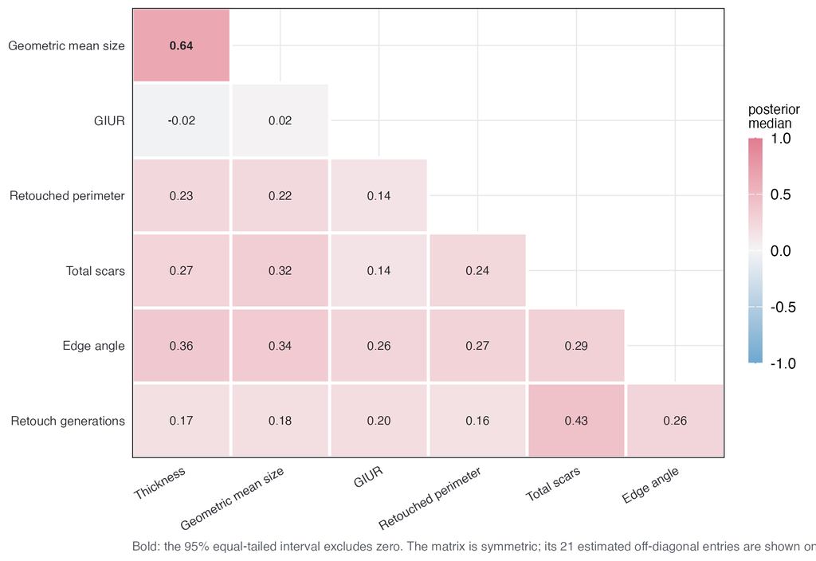

Figure 11: Posterior median of each of the 21 locality-intercept correlations. Bold entries are those whose 95% equal-tailed interval excludes zero.

Table 24: All 21 correlations among the locality intercepts, ordered by absolute posterior median. With 26 clusters these are weakly identified; the LKJ(1) prior is uniform over correlation matrices and S5 varies it.

| Response A | Response B | median | 2.5% | 97.5% | mode | HDI lo | HDI hi | P(rho > 0) | Rhat | ESS bulk |
| --- | --- | --- | --- | --- | --- | --- | --- | --- | --- | --- |
| Thickness | Geometric mean size | 0.636 | 0.109 | 0.912 | 0.726 | 0.179 | 0.942 | 0.988 | 1.000 | 8384 |
| Total scars | Retouch generations | 0.434 | -0.282 | 0.850 | 0.531 | -0.198 | 0.890 | 0.895 | 1.000 | 10288 |
| Thickness | Edge angle | 0.351 | -0.234 | 0.798 | 0.351 | -0.186 | 0.828 | 0.884 | 1.000 | 11616 |
| Geometric mean size | Edge angle | 0.336 | -0.230 | 0.773 | 0.367 | -0.173 | 0.812 | 0.881 | 1.000 | 15143 |
| Geometric mean size | Total scars | 0.311 | -0.255 | 0.765 | 0.306 | -0.224 | 0.787 | 0.859 | 1.000 | 11722 |
| Total scars | Edge angle | 0.298 | -0.307 | 0.761 | 0.340 | -0.266 | 0.790 | 0.831 | 1.000 | 14701 |
| Retouched perimeter | Edge angle | 0.276 | -0.420 | 0.786 | 0.357 | -0.364 | 0.822 | 0.783 | 1.000 | 10579 |
| Edge angle | Retouch generations | 0.260 | -0.390 | 0.757 | 0.332 | -0.367 | 0.769 | 0.781 | 1.000 | 14663 |
| Thickness | Total scars | 0.258 | -0.332 | 0.749 | 0.328 | -0.302 | 0.770 | 0.800 | 1.000 | 9440 |
| GIUR | Edge angle | 0.251 | -0.378 | 0.753 | 0.290 | -0.335 | 0.785 | 0.779 | 1.000 | 12107 |
| Retouched perimeter | Total scars | 0.241 | -0.451 | 0.772 | 0.266 | -0.402 | 0.808 | 0.750 | 1.000 | 8196 |
| Thickness | Retouched perimeter | 0.228 | -0.451 | 0.761 | 0.267 | -0.404 | 0.792 | 0.743 | 1.000 | 15265 |
| Geometric mean size | Retouched perimeter | 0.219 | -0.445 | 0.751 | 0.215 | -0.394 | 0.794 | 0.733 | 1.000 | 17288 |
| GIUR | Retouch generations | 0.197 | -0.491 | 0.746 | 0.246 | -0.442 | 0.782 | 0.699 | 1.000 | 10384 |
| Geometric mean size | Retouch generations | 0.185 | -0.429 | 0.710 | 0.251 | -0.421 | 0.715 | 0.715 | 1.000 | 13903 |
| Retouched perimeter | Retouch generations | 0.176 | -0.530 | 0.746 | 0.270 | -0.488 | 0.775 | 0.681 | 1.000 | 10048 |
| Thickness | Retouch generations | 0.164 | -0.463 | 0.720 | 0.195 | -0.449 | 0.730 | 0.686 | 1.000 | 12492 |
| GIUR | Total scars | 0.138 | -0.481 | 0.685 | 0.169 | -0.460 | 0.704 | 0.662 | 1.000 | 10724 |
| GIUR | Retouched perimeter | 0.137 | -0.537 | 0.729 | 0.115 | -0.510 | 0.754 | 0.648 | 1.000 | 15548 |
| Thickness | GIUR | -0.026 | -0.590 | 0.597 | -0.045 | -0.605 | 0.577 | 0.470 | 1.001 | 7595 |
| Geometric mean size | GIUR | 0.016 | -0.534 | 0.596 | -0.061 | -0.547 | 0.578 | 0.518 | 1.000 | 10821 |

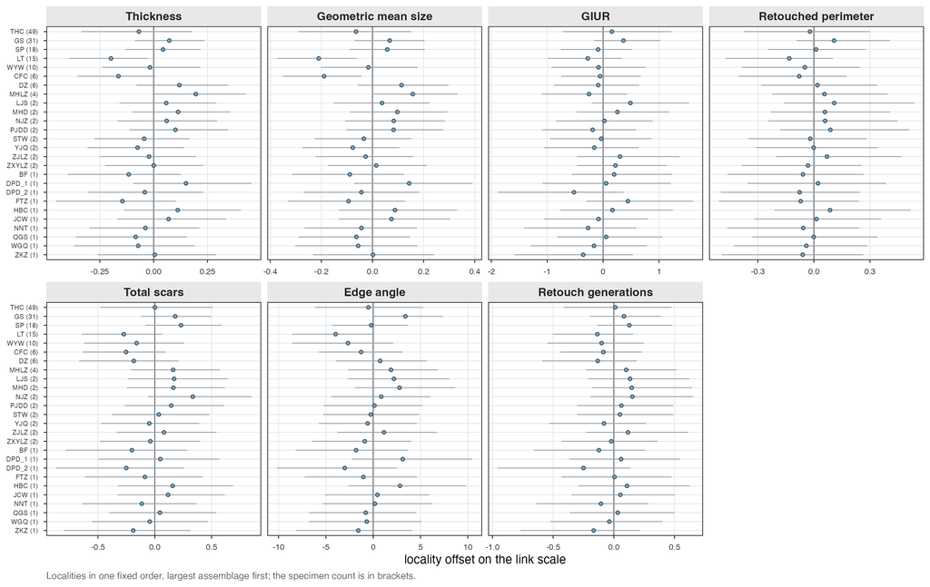

Figure 12: Locality offsets on the link scale, one panel per response, with 95% equal-tailed intervals. Localities are in one fixed order in every panel, largest assemblage first, with the specimen count in brackets. Reading down each panel shows partial pooling at work: the smaller the assemblage, the harder the offset is pulled towards zero and the wider its interval.

# 13 Appendix F. Sensitivity Analysis in Full

Cf. BARG Step 5.

Seven fits, identical in every respect except the prior, each changing one element of the reference specification. A full factorial would have made any movement impossible to attribute, so the design here changes one thing at a time (Section 5). S1 is the unscaled `normal(0, 1)` slope prior discussed in Section 4.5, which is also the specification `paper/_analysis.R` uses for the main paper’s summary tables (Section 7).

S6 differs in kind from the rest. S1 to S5 vary how much the data are allowed to say about a quantity the report decides on; S6 removes a parameter the data cannot inform, so its curves in Figure 13 and Figure 14 coincide with the reference by construction (Section 4.4.3).

Table 25: The seven prior specifications. REF is the reference; each of S1 to S6 changes exactly one line of it.

| Fit | Prior change | Rationale |
| --- | --- | --- |
| REF | b: normal(0, SD_link); sd: student_t(3, 0, 2); cor: lkj(1) | reference |
| S1 | b: normal(0, 1) | the original specification, kept for comparison |
| S2 | b: normal(0, 2.5 x SD_link) | slopes two and a half times wider |
| S3 | sd: exponential(1) | locality SD; 26 clusters make this prior influential |
| S4 | sd: normal(0, 1) truncated at zero | locality SD, a lighter tail than the half-t |
| S5 | cor: lkj(2) | 26 clusters and 21 correlations; lkj(2) shrinks towards zero |
| S6 | coi: constant(1) | one-inflated beta; there are no zeros for coi to describe |

## 13.1 Broad Prior

Cf. BARG Step 5.A.

S2 widens every slope prior by a factor of 2.5, to `normal(0, 2.5 x SD_link)`. This is the broad prior the guideline asks for: if the posterior barely moves when the prior becomes two and a half times more permissive, the result rests on the data instead of on the prior. S3 and S4 play the same role for the locality SD, and S5 for the correlation matrix.

## 13.2 Variations of the Default Priors

Cf. BARG Step 5.C.

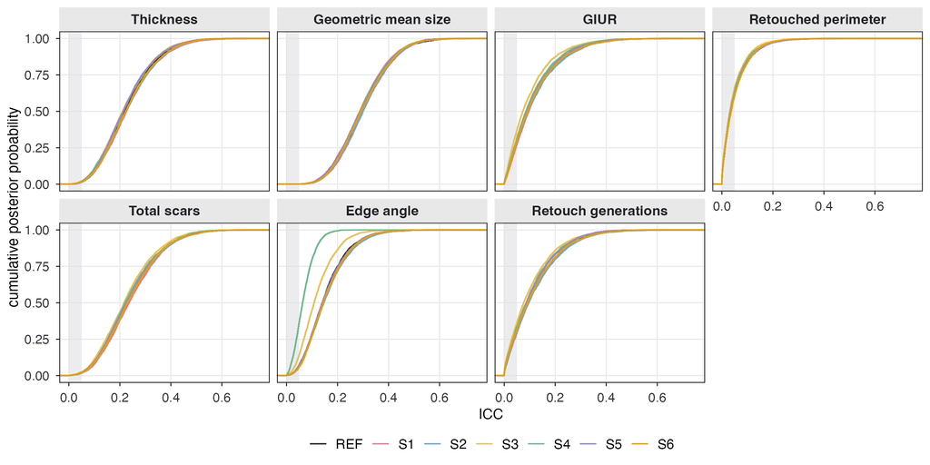

Figure 13: Q1 under all seven priors: the cumulative posterior distribution of each ICC. The shaded band is the ICC ROPE [0, 0.05]. A curve’s height where it crosses the right edge of the band is P(ICC <= 0.05).

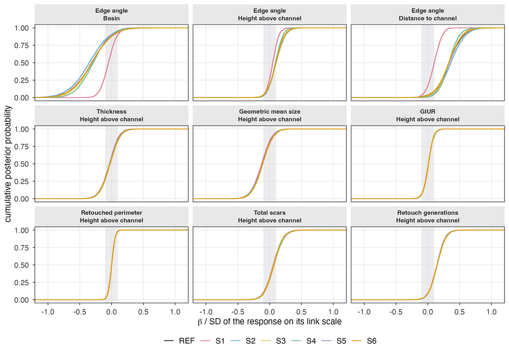

Figure 14: Q2 under all seven priors, for the slopes most exposed to the prior: the three edge-angle slopes (the response that was prior-dominated under the original specification) and the height slope of every response. Cumulative distributions on the standardised axis, with the ROPE shaded.

The curves are cumulative distributions rather than densities, because this report’s summaries are quantiles: a horizontal slice at 0.025 and 0.975 reads off the interval limits directly, and the vertical distance between two curves at the ROPE edge is the change in the quantity the decision rule uses.

BARG recommends providing the numbers as well as the pictures, and for every parameter rather than only the plotted ones:

Table 26: Posterior median and 95% equal-tailed interval for every ICC and every slope, under each of the seven priors. Slopes are standardised by the link-scale SD of their response.

| Quantity | REF | S1 | S2 | S3 | S4 | S5 | S6 |
| --- | --- | --- | --- | --- | --- | --- | --- |
| ICC: Thickness | 0.22 [0.06, 0.47] | 0.22 [0.06, 0.48] | 0.23 [0.06, 0.48] | 0.21 [0.06, 0.45] | 0.21 [0.06, 0.46] | 0.21 [0.06, 0.46] | 0.22 [0.06, 0.47] |
| ICC: Geometric mean size | 0.29 [0.12, 0.52] | 0.30 [0.13, 0.53] | 0.30 [0.12, 0.53] | 0.29 [0.12, 0.51] | 0.29 [0.12, 0.51] | 0.29 [0.12, 0.51] | 0.29 [0.12, 0.53] |
| ICC: GIUR | 0.09 [0.00, 0.38] | 0.10 [0.00, 0.37] | 0.10 [0.00, 0.38] | 0.07 [0.00, 0.33] | 0.08 [0.00, 0.34] | 0.09 [0.00, 0.37] | 0.09 [0.00, 0.37] |
| ICC: Retouched perimeter | 0.04 [0.00, 0.21] | 0.04 [0.00, 0.21] | 0.04 [0.00, 0.21] | 0.03 [0.00, 0.19] | 0.03 [0.00, 0.20] | 0.03 [0.00, 0.20] | 0.04 [0.00, 0.21] |
| ICC: Total scars | 0.23 [0.05, 0.49] | 0.24 [0.06, 0.50] | 0.24 [0.06, 0.50] | 0.22 [0.05, 0.48] | 0.22 [0.06, 0.48] | 0.23 [0.05, 0.49] | 0.23 [0.06, 0.49] |
| ICC: Edge angle | 0.14 [0.03, 0.37] | 0.14 [0.03, 0.36] | 0.14 [0.03, 0.36] | 0.11 [0.02, 0.30] | 0.06 [0.01, 0.16] | 0.14 [0.03, 0.36] | 0.14 [0.03, 0.36] |
| ICC: Retouch generations | 0.09 [0.00, 0.37] | 0.10 [0.00, 0.37] | 0.10 [0.00, 0.37] | 0.08 [0.00, 0.34] | 0.08 [0.00, 0.35] | 0.08 [0.00, 0.36] | 0.09 [0.00, 0.37] |
| Thickness ~ Basin (Huangping vs Binchuan) | -0.21 [-0.81, 0.42] | -0.19 [-0.85, 0.48] | -0.25 [-0.91, 0.44] | -0.21 [-0.81, 0.41] | -0.21 [-0.80, 0.42] | -0.21 [-0.81, 0.41] | -0.21 [-0.81, 0.42] |
| Thickness ~ Height above channel (z) | -0.03 [-0.29, 0.23] | -0.03 [-0.30, 0.22] | -0.02 [-0.29, 0.24] | -0.02 [-0.28, 0.22] | -0.03 [-0.28, 0.23] | -0.02 [-0.28, 0.24] | -0.02 [-0.28, 0.23] |
| Thickness ~ Distance to channel (z) | 0.27 [-0.14, 0.71] | 0.23 [-0.20, 0.72] | 0.30 [-0.13, 0.78] | 0.27 [-0.14, 0.71] | 0.27 [-0.15, 0.70] | 0.27 [-0.16, 0.72] | 0.28 [-0.14, 0.72] |
| Geometric mean size ~ Basin (Huangping vs Binchuan) | -0.30 [-0.96, 0.38] | -0.28 [-1.00, 0.43] | -0.34 [-1.08, 0.37] | -0.30 [-0.95, 0.36] | -0.30 [-0.96, 0.36] | -0.30 [-0.96, 0.37] | -0.29 [-0.95, 0.39] |
| Geometric mean size ~ Height above channel (z) | -0.12 [-0.40, 0.15] | -0.12 [-0.41, 0.14] | -0.11 [-0.39, 0.16] | -0.11 [-0.39, 0.15] | -0.12 [-0.39, 0.15] | -0.12 [-0.39, 0.16] | -0.11 [-0.39, 0.16] |
| Geometric mean size ~ Distance to channel (z) | 0.16 [-0.30, 0.64] | 0.12 [-0.36, 0.66] | 0.19 [-0.29, 0.71] | 0.16 [-0.30, 0.64] | 0.16 [-0.29, 0.65] | 0.16 [-0.30, 0.66] | 0.17 [-0.30, 0.67] |
| GIUR ~ Basin (Huangping vs Binchuan) | -0.02 [-0.39, 0.33] | -0.01 [-0.34, 0.33] | -0.03 [-0.41, 0.33] | -0.03 [-0.36, 0.30] | -0.03 [-0.37, 0.30] | -0.03 [-0.38, 0.32] | -0.03 [-0.39, 0.32] |
| GIUR ~ Height above channel (z) | 0.01 [-0.13, 0.16] | 0.01 [-0.14, 0.15] | 0.01 [-0.14, 0.15] | 0.01 [-0.13, 0.15] | 0.01 [-0.13, 0.15] | 0.01 [-0.14, 0.16] | 0.01 [-0.13, 0.15] |
| GIUR ~ Distance to channel (z) | -0.02 [-0.30, 0.20] | -0.04 [-0.32, 0.17] | -0.02 [-0.31, 0.21] | -0.02 [-0.27, 0.19] | -0.02 [-0.29, 0.20] | -0.02 [-0.29, 0.20] | -0.02 [-0.30, 0.20] |
| Retouched perimeter ~ Basin (Huangping vs Binchuan) | -0.00 [-0.22, 0.20] | 0.00 [-0.21, 0.21] | -0.01 [-0.23, 0.20] | -0.01 [-0.22, 0.20] | -0.01 [-0.22, 0.20] | -0.00 [-0.22, 0.20] | -0.01 [-0.22, 0.21] |
| Retouched perimeter ~ Height above channel (z) | 0.00 [-0.09, 0.09] | 0.00 [-0.09, 0.09] | 0.00 [-0.09, 0.09] | 0.00 [-0.09, 0.09] | 0.00 [-0.09, 0.09] | 0.00 [-0.09, 0.09] | 0.00 [-0.09, 0.09] |
| Retouched perimeter ~ Distance to channel (z) | 0.06 [-0.06, 0.20] | 0.06 [-0.08, 0.19] | 0.07 [-0.06, 0.20] | 0.06 [-0.06, 0.19] | 0.07 [-0.06, 0.19] | 0.06 [-0.06, 0.20] | 0.06 [-0.06, 0.20] |
| Total scars ~ Basin (Huangping vs Binchuan) | -0.12 [-0.75, 0.50] | -0.10 [-0.77, 0.54] | -0.16 [-0.85, 0.49] | -0.14 [-0.75, 0.45] | -0.13 [-0.76, 0.47] | -0.14 [-0.76, 0.47] | -0.13 [-0.75, 0.48] |
| Total scars ~ Height above channel (z) | 0.07 [-0.18, 0.33] | 0.06 [-0.19, 0.33] | 0.07 [-0.18, 0.33] | 0.06 [-0.18, 0.32] | 0.06 [-0.18, 0.32] | 0.07 [-0.19, 0.33] | 0.07 [-0.19, 0.33] |
| Total scars ~ Distance to channel (z) | 0.19 [-0.27, 0.63] | 0.16 [-0.32, 0.62] | 0.21 [-0.26, 0.68] | 0.20 [-0.26, 0.62] | 0.19 [-0.26, 0.64] | 0.20 [-0.25, 0.63] | 0.20 [-0.26, 0.64] |
| Edge angle ~ Basin (Huangping vs Binchuan) | -0.31 [-0.85, 0.21] | -0.05 [-0.27, 0.17] | -0.35 [-0.92, 0.20] | -0.31 [-0.81, 0.18] | -0.29 [-0.74, 0.14] | -0.32 [-0.84, 0.22] | -0.32 [-0.85, 0.22] |
| Edge angle ~ Height above channel (z) | 0.10 [-0.12, 0.33] | 0.05 [-0.12, 0.21] | 0.10 [-0.12, 0.34] | 0.10 [-0.12, 0.31] | 0.09 [-0.10, 0.29] | 0.10 [-0.12, 0.33] | 0.10 [-0.12, 0.34] |
| Edge angle ~ Distance to channel (z) | 0.34 [-0.02, 0.70] | 0.10 [-0.11, 0.30] | 0.36 [-0.02, 0.74] | 0.34 [0.01, 0.67] | 0.33 [0.06, 0.61] | 0.34 [-0.03, 0.70] | 0.34 [-0.02, 0.71] |
| Retouch generations ~ Basin (Huangping vs Binchuan) | -0.29 [-0.81, 0.22] | -0.28 [-0.82, 0.25] | -0.32 [-0.88, 0.22] | -0.30 [-0.81, 0.20] | -0.29 [-0.81, 0.21] | -0.29 [-0.81, 0.21] | -0.29 [-0.82, 0.21] |
| Retouch generations ~ Height above channel (z) | 0.15 [-0.07, 0.37] | 0.14 [-0.08, 0.36] | 0.15 [-0.07, 0.38] | 0.14 [-0.07, 0.36] | 0.14 [-0.08, 0.37] | 0.15 [-0.08, 0.37] | 0.15 [-0.07, 0.37] |
| Retouch generations ~ Distance to channel (z) | 0.26 [-0.10, 0.60] | 0.24 [-0.14, 0.58] | 0.28 [-0.09, 0.63] | 0.27 [-0.07, 0.59] | 0.26 [-0.09, 0.59] | 0.26 [-0.08, 0.60] | 0.27 [-0.10, 0.61] |

## 13.3 Do the Conclusions Change Between Fits??

Cf. BARG Step 5.E. Some movement is inevitable, so the criterion is whether the numbers moved enough, relative to the width of the posterior interval and relative to the ROPE, to change a conclusion.

Section 6.5 gives the summary and quotes the largest movement of a posterior median across the seven priors. The table here gives the detail behind the decisions: what each quantity is judged to be under each prior. Table 26 above supplies the estimates those judgements come from.

Table 27: The decision each quantity receives under each prior.

| Quantity | REF | S1 | S2 | S3 | S4 | S5 | S6 |
| --- | --- | --- | --- | --- | --- | --- | --- |
| ICC: Thickness | locality variation present | locality variation present | locality variation present | locality variation present | locality variation present | locality variation present | locality variation present |
| ICC: Geometric mean size | locality variation present | locality variation present | locality variation present | locality variation present | locality variation present | locality variation present | locality variation present |
| ICC: GIUR | undecided | undecided | undecided | undecided | undecided | undecided | undecided |
| ICC: Retouched perimeter | undecided | undecided | undecided | undecided | undecided | undecided | undecided |
| ICC: Total scars | locality variation present | locality variation present | locality variation present | undecided | locality variation present | locality variation present | locality variation present |
| ICC: Edge angle | undecided | undecided | undecided | undecided | undecided | undecided | undecided |
| ICC: Retouch generations | undecided | undecided | undecided | undecided | undecided | undecided | undecided |
| Thickness ~ Basin (Huangping vs Binchuan) | undecided | undecided | undecided | undecided | undecided | undecided | undecided |
| Thickness ~ Height above channel (z) | undecided | undecided | undecided | undecided | undecided | undecided | undecided |
| Thickness ~ Distance to channel (z) | undecided | undecided | undecided | undecided | undecided | undecided | undecided |
| Geometric mean size ~ Basin (Huangping vs Binchuan) | undecided | undecided | undecided | undecided | undecided | undecided | undecided |
| Geometric mean size ~ Height above channel (z) | undecided | undecided | undecided | undecided | undecided | undecided | undecided |
| Geometric mean size ~ Distance to channel (z) | undecided | undecided | undecided | undecided | undecided | undecided | undecided |
| GIUR ~ Basin (Huangping vs Binchuan) | undecided | undecided | undecided | undecided | undecided | undecided | undecided |
| GIUR ~ Height above channel (z) | undecided | undecided | undecided | undecided | undecided | undecided | undecided |
| GIUR ~ Distance to channel (z) | undecided | undecided | undecided | undecided | undecided | undecided | undecided |
| Retouched perimeter ~ Basin (Huangping vs Binchuan) | undecided | undecided | undecided | undecided | undecided | undecided | undecided |
| Retouched perimeter ~ Height above channel (z) | accept the null value | accept the null value | accept the null value | accept the null value | accept the null value | accept the null value | accept the null value |
| Retouched perimeter ~ Distance to channel (z) | undecided | undecided | undecided | undecided | undecided | undecided | undecided |
| Total scars ~ Basin (Huangping vs Binchuan) | undecided | undecided | undecided | undecided | undecided | undecided | undecided |
| Total scars ~ Height above channel (z) | undecided | undecided | undecided | undecided | undecided | undecided | undecided |
| Total scars ~ Distance to channel (z) | undecided | undecided | undecided | undecided | undecided | undecided | undecided |
| Edge angle ~ Basin (Huangping vs Binchuan) | undecided | undecided | undecided | undecided | undecided | undecided | undecided |
| Edge angle ~ Height above channel (z) | undecided | undecided | undecided | undecided | undecided | undecided | undecided |
| Edge angle ~ Distance to channel (z) | undecided | undecided | undecided | undecided | undecided | undecided | undecided |
| Retouch generations ~ Basin (Huangping vs Binchuan) | undecided | undecided | undecided | undecided | undecided | undecided | undecided |
| Retouch generations ~ Height above channel (z) | undecided | undecided | undecided | undecided | undecided | undecided | undecided |
| Retouch generations ~ Distance to channel (z) | undecided | undecided | undecided | undecided | undecided | undecided | undecided |

# 14 Appendix G. BARG Conformance

Kruschke (2021) sets out a checklist for reporting a Bayesian analysis. The table below places every item on it against the section that answers it. The same checklist can be walked from the other direction: each section of this document opens with a shaded box naming the item it addresses.

This table sits at the end rather than at the front because the narrative of this document follows the order of the work rather than the order of the checklist (Section 1). A reader auditing coverage should start here; a reader following the argument will have passed every row already.

[output not shown]

## 14.1 What the Checklist Does Not Ask For

Three parts of this document answer to the second standard rather than to this one, and a reader auditing BARG coverage will not find rows for them. Section 3 states the estimand and the design before any model appears, so that the resolution of both research questions is fixed in the open rather than inferred from wide intervals later. Section 5 sets out all eleven fits together with the reason each exists, including the two that record a defect the analysis found in itself. Section 10.5 checks that the reference posterior is calibrated, which no item on the checklist asks for and no convergence diagnostic can supply — and which this report needs, because both of the defects it found in itself were invisible to every diagnostic it reports. None of the three is required by Kruschke (2021), and each is standard in Gelman, Vehtari, McElreath, et al. (2026).

# 15 References

Bürkner, P.-C. (2017). brms: An R package for Bayesian multilevel models using Stan. *Journal of Statistical Software*, 80(1), 1–28.

Eerkens, J. W., & Bettinger, R. L. (2001). Techniques for assessing standardization in artifact assemblages: can we scale material variability? *American Antiquity*, 66(3), 493–504.

Gelman, A., Vehtari, A., & McElreath, R., with Simpson, D., Margossian, C. C., Yao, Y., Kennedy, L., Gabry, J., Bürkner, P.-C., Modrák, M., & Leos Barajas, V. (2026). *Bayesian Workflow*. CRC Press.

Kruschke, J. K. (2018). Rejecting or accepting parameter values in Bayesian estimation. *Advances in Methods and Practices in Psychological Science*, 1(2), 270–280.

Kruschke, J. K. (2021). Bayesian analysis reporting guidelines. *Nature Human Behaviour*, 5, 1282–1291.

Modrák, M., Moon, A. H., Kim, S., Bürkner, P.-C., Huurre, N., Faltejsková, K., Gelman, A., & Vehtari, A. (2025). Simulation-based calibration checking for Bayesian computation: the choice of test quantities shapes sensitivity. *Bayesian Analysis*, 20, 461–488.

Säilynoja, T., Schmitt, M., Bürkner, P.-C., & Vehtari, A. (2026). Posterior SBC: simulation-based calibration checking conditional on data. *Statistics and Computing*, 36, 78.

Vehtari, A., Gelman, A., Simpson, D., Carpenter, B., & Bürkner, P.-C. (2021). Rank-normalization, folding, and localization: an improved $\hat R$ for assessing convergence of MCMC. *Bayesian Analysis*, 16(2), 667–718.